# 语言主要是一种交流工具，而非思维工具

# Language is primarily a tool for communication rather than thought

Evelina Fedorenko<sup>1,2</sup>、Steven T. Piantadosi<sup>3</sup> 与 Edward A. F. Gibson<sup>1</sup>

Evelina Fedorenko<sup>1,2</sup>, Steven T. Piantadosi<sup>3</sup> & Edward A. F. Gibson<sup>1</sup>

*Nature* 第 630 卷，2024 年 6 月 20 日，575–586 页（观点文章）。https://doi.org/10.1038/s41586-024-07522-w。收稿：2023 年 2 月 15 日；接受：2024 年 5 月 3 日；在线发表：2024 年 6 月 19 日。

*Nature* Vol 630, 20 June 2024, 575–586 (Perspective). https://doi.org/10.1038/s41586-024-07522-w. Received: 15 February 2023; Accepted: 3 May 2024; Published online: 19 June 2024.

<sup>1</sup>美国马萨诸塞州剑桥，麻省理工学院。<sup>2</sup>美国马萨诸塞州波士顿，哈佛大学言语与听觉生物科学与技术项目。<sup>3</sup>美国加利福尼亚州伯克利，加州大学伯克利分校。电子邮件：evelina9@mit.edu

<sup>1</sup>Massachusetts Institute of Technology, Cambridge, MA, USA. <sup>2</sup>Speech and Hearing in Bioscience and Technology Program at Harvard University, Boston, MA, USA. <sup>3</sup>University of California, Berkeley, Berkeley, CA, USA. e-mail: evelina9@mit.edu

**语言是我们这一物种的决定性特征，但它所服务的功能（一种或多种）已争论了数个世纪。本文我们援引来自神经科学及相关学科的最新证据，论证在现代人类中，语言是一种交流工具，这与“我们用语言来思考”这一颇具影响的观点相反。我们首先介绍支持人类语言能力的脑网络；随后回顾语言与思维之间存在双重分离的证据，并讨论语言的若干特性，这些特性表明语言是为交流而优化的。我们的结论是：尽管语言的出现无疑改变了人类文化，但语言似乎并不是复杂思维（包括符号思维）的先决条件。相反，语言是传递文化知识的强大工具；它很可能与我们的思维和推理能力协同演化，并且只是反映了、而非造就了人类认知标志性的复杂精妙。**

**Language is a defining characteristic of our species, but the function, or functions, that it serves has been debated for centuries. Here we bring recent evidence from neuroscience and allied disciplines to argue that in modern humans, language is a tool for communication, contrary to a prominent view that we use language for thinking. We begin by introducing the brain network that supports linguistic ability in humans. We then review evidence for a double dissociation between language and thought, and discuss several properties of language that suggest that it is optimized for communication. We conclude that although the emergence of language has unquestionably transformed human culture, language does not appear to be a prerequisite for complex thought, including symbolic thought. Instead, language is a powerful tool for the transmission of cultural knowledge; it plausibly co-evolved with our thinking and reasoning capacities, and only reflects, rather than gives rise to, the signature sophistication of human cognition.**

据估计，语言在人类中出现于距今 10 万至 100 万年之间<sup>1</sup>。语言的功能及其起源的因果驱动因素，长期以来在哲学、语言学、认知科学、进化生物学和人类学等众多领域中争论激烈。主导这一讨论的有两大类假说，尽管二者并不相互排斥。一种观点认为，语言主要服务于交流功能——它使我们能够彼此分享知识、想法和感受<sup>2–7</sup>。另一种观点认为，语言介导思维和认知<sup>8–13</sup>。关于语言在思维中作用的具体假说，从强主张（语言是所有形式的思维——至少是命题性思维——所必需的<sup>14,15</sup>），到较弱的主张（语言可能只对思维与推理的某些方面至关重要，或能促进这些方面<sup>9,16</sup>），再到认为语言在发展过程中帮助搭建某些类型学习的“脚手架”、但在成熟大脑中可能不再需要的主张<sup>12,17,18</sup>（专栏 1），不一而足。

Language is estimated to have emerged in humans between 100,000 and 1,000,000 years ago<sup>1</sup>. The functions of language and the causal drivers in its origins have long been fiercely debated across diverse fields, including philosophy, linguistics, cognitive science, evolutionary biology and anthropology. Two broad hypotheses have dominated this discussion, although they are not mutually exclusive. One proposal is that language primarily serves a communicative function—it enables us to share knowledge, thoughts, and feelings with one another<sup>2–7</sup>. Another proposal is that language mediates thinking and cognition<sup>8–13</sup>. The specific hypotheses about the role of language in thinking have ranged from strong claims that language is necessary for all forms of (at least propositional) thought<sup>14,15</sup>, to weaker claims that language may only be critical for, or can facilitate, certain aspects of thinking and reasoning<sup>9,16</sup>, and claims that language helps scaffold certain kinds of learning during development but may no longer be needed in mature brains<sup>12,17,18</sup> (Box 1).

从进化适应度的角度看，语言的交流功能和认知功能都可能带来适应性优势。准确传递信息的能力很可能有助于狩猎、拾荒和长途迁徙等合作行为，并使知识和技能得以传给后代（文化传递）。推理能力的提升则很可能带来更复杂的计划与决策、更好的工具制造以及更强的问题解决能力。然而，关于认知特征进化起源的假说是出了名的难以评估<sup>19</sup>。关于早期人族生活的主要证据来自稀少的考古记录。大脑不会形成化石；即便能形成化石，从大脑的大小、形状和解剖结构中也只能获得关于脑功能的粗略信息。此外，某些特征可能因某一原因而进化，随后却因物种生态的变化而服务于不同的功能：这种现象被称为扩展适应（exaptation）<sup>20</sup>。鉴于这些挑战，我们并不打算对语言的进化起源做出强有力的论断。不过，我们确实就语言在现代人类中的功能提出论证，并讨论塑造了语言的优化压力。

From an evolutionary fitness standpoint, both the communicative and the cognitive functions of language could provide adaptive advantages. An ability to accurately transmit information would plausibly facilitate cooperative behaviours such as hunting, scavenging and long-distance travel, and enable passing of knowledge and skills to offspring (cultural transmission). An improved reasoning capacity would plausibly enable more sophisticated planning and decision making, creation of better tools and better problem-solving abilities. However, hypotheses about the evolutionary origins of cognitive traits are notoriously challenging to evaluate<sup>19</sup>. The primary evidence about the lives of early hominins comes from sparse archaeological records. Brains do not fossilize, and even if they did, only coarse information about brain function could be gleaned from brain size, shape and anatomy. Moreover, certain traits may evolve for one reason but subsequently serve a different function owing to changes in the species’ ecology: a phenomenon known as exaptation<sup>20</sup>. As a result of these challenges, we do not aspire to make strong claims about the evolutionary origins of language. We do, however, make an argument about the function of language in modern humans and discuss optimization pressures that have shaped language.

“语言用于思维”与“语言用于交流”这两种主张，至少其中某些变体对人类的认知与神经架构以及人类语言的特性做出了可检验的预测。是否有任何形式的思维——我们关于世界的知识以及基于这些知识表征进行推理的能力——需要语言（即支持我们生成和理解具有意义结构的词序列的表征与计算）？如果某些形式的思维需要语言，那么至少在这些类型的思维与推理中，语言机制应当被必然地调用，而且没有语言，这些类型的思维就不可能发生。如果语言是一种交流工具，那么语言应当显示出高效信息传递的标志性特征。直到最近，这些预测都难以评估。然而，在过去二十年间，已出现了能够为语言功能提供关键启示的知识和工具。首先，在破解语言的神经架构方面取得了重大进展，为评估各种形式的思维过程中语言加工机制是否被调用提供了明确的“靶标”。其次，大量多样语言的语料库已广泛可得，同时出现了一套强大的计算工具（通常基于信息论<sup>21</sup>），可用于严格刻画语言系统。因此，现在正是盘点关于语言功能及其在人类认知中作用这些重大问题之现有证据的时机。

At least some variants of both the language-for-thought and the language-for-communication proposals make testable predictions about human cognitive and neural architecture and about the properties of human languages. Do any forms of thought—our knowledge of the world and ability to reason over these knowledge representations—require language (that is, representations and computations that support our ability to generate and interpret meaningfully structured word sequences)? If some forms of thought require language, then linguistic mechanisms should be obligatorily engaged for at least those types of thinking and reasoning, and those types of thought should not be possible without language. If language is a tool for communication, then language should show hallmarks of efficient information transfer. Until recently, these predictions have been difficult to evaluate. However, over the past two decades, knowledge and tools have become available that have shed critical light on the function of language. First, substantial advances have been made in deciphering the neural architecture of language, providing a clear ‘target’ for evaluating the engagement of language-processing mechanisms during various forms of thought. Second, massive corpora of diverse languages have become widely available, along with a suite of powerful computational tools, often based on information theory<sup>21</sup>, for rigorously characterizing linguistic systems. As a result, the time is now ripe to take stock of current evidence on the big and important questions of the function of language and its role in human cognition.

## 人脑中的语言网络

## The language network in the human brain

我们的语言知识涵盖语言结构各个层面（从语音到句子）的规律性知识，以及大量的形式–意义映射<sup>22,23</sup>（语素、词和构式的意义）。借助这些知识，我们既能向他人传达自己的想法，也能从他人的话语中推断其意图表达的意义。语言产出和语言理解由左半球一组相互连接的脑区支持，这组脑区常被称为“语言网络”<sup>24–27</sup>（近期综述见参考文献 28）（图 1a；专栏 2 描述了它与语言神经生物学“经典模型”的关系）。

Our knowledge of language encompasses knowledge of regularities at all levels of linguistic structure, from sounds to sentences, and a large set of form–meaning mappings<sup>22,23</sup> (meanings of morphemes, words and constructions). Using this knowledge, we can both convey our thoughts to others and infer others’ intended meanings from their utterances. Language production and language understanding are supported by an interconnected set of brain areas in the left hemisphere, often referred to as the ‘language network’<sup>24–27</sup> (recently reviewed in ref. 28) (Fig. 1a; Box 2 describes its relationship to the ‘classic model’ of the neurobiology of language).

语言网络的两个特性对于讨论语言的功能至关重要。第一，语言脑区表现出对输入和输出模态的独立性——这是表征抽象性的关键标志。首先，在理解过程中，这些脑区对各种模态（口语、书面语或手语<sup>29–32</sup>）的语言输入均有反应。同样，在语言生成过程中，无论我们是通过说还是写来产出信息，这些脑区都会激活<sup>33</sup>。这些脑区同时支持理解和产出<sup>33,34</sup>（图 1a），这表明它们很可能储存着我们的语言知识，而编码和解码语言信息都需要这些知识。语言网络表征的抽象性表明，该网络对应于 Hauser、Chomsky 和 Fitch 在一篇关于语言进化的有影响力的文章<sup>35</sup>中所称的“狭义语言官能”，即一个独立于较低层级的言语感知和言语发音机制的“抽象计算系统”（专栏 2）。

Two properties of the language network are important for the discussion of the function(s) of language. First, the language areas exhibit independence of input and output modalities—key signatures of representational abstractness. First, during comprehension, these brain areas respond to linguistic input across modalities (spoken, written or signed<sup>29–32</sup>). Similarly, during language generation, these areas are active regardless of whether we produce our messages by speaking or writing<sup>33</sup>. The fact that these areas support both comprehension and production<sup>33,34</sup> (Fig. 1a) suggests that they are likely to store our linguistic knowledge, which is needed to both encode and decode linguistic messages. The abstractness of the language network’s representations suggests that this network corresponds to what Hauser, Chomsky and Fitch, in an influential piece on language evolution<sup>35</sup>, referred to as “the faculty of language in the narrow sense” or an “abstract computational system” that is separate from lower-level speech perception and speech articulation mechanisms (Box 2).

第二，语言脑区既表征和加工词义，也表征和加工句法结构——这是对“语言用于思维”诸假说至关重要的两个语言成分（专栏 1）。具体而言，来自功能磁共振成像（fMRI）、脑磁图和颅内记录研究中多种实验范式与自然范式的证据表明，语言网络的所有脑区都对词义以及词与词之间的句法和语义依存关系敏感<sup>33,36–48</sup>（图 1a）。综上，语言网络中语言表征的抽象性及其对语言意义和结构的敏感性，使它成为评估关于语言在思维与认知中作用的各种假说的明确靶标（专栏 3）。

Second, the language areas represent and process both word meanings and syntactic structure—two components of language that are important to the language-for-thought hypotheses (Box 1). In particular, evidence from diverse experimental and naturalistic paradigms in functional MRI (fMRI), magnetoencephalography and intracranial recording studies has revealed that all areas of the language network are sensitive to word meanings and to inter-word syntactic and semantic dependencies<sup>33,36–48</sup> (Fig. 1a). Together, the abstractness of the linguistic representations in the language network and the sensitivity of the network to linguistic meaning and structure make it a clear target for evaluating hypotheses about the role of language in thought and cognition (Box 3).

## 语言对于思维既不必要也不充分

## Language is not necessary or sufficient for thought

人类认知的本体论以及介导思维的心理表征的本质（专栏 3）仍是活跃的研究领域。宽泛地说，思维包括我们关于世界的知识（包括特定领域的知识，如关于物体物理属性的知识或关于社会主体的知识），以及基于这些知识表征进行的推理，其中包括做出推断和预测。除了针对特定知识领域的推理之外，推理还可能涉及跨领域的信息整合（这是类比推理的重要成分<sup>49</sup>），或者是领域一般性的、脱离任何特定领域的推理。领域一般性推理常与流体智力的概念相联系<sup>50</sup>。由于各种“语言用于思维”假说在语言被认为对思维或认知的哪些方面至关重要或有帮助这一点上各不相同（专栏 1），而我们的目标是对这一观点做广泛评估，因此我们将讨论来自多种调用思维与推理的范式的证据。此外，从经验上看，迄今测试过的思维的所有方面在调用语言资源方面表现相似。

The ontology of human cognition and the nature of mental representations that mediate thought (Box 3) remain active areas of research. Broadly, thought encompasses our knowledge of the world (including particular domains, such as knowledge of the physical properties of objects or knowledge of social agents) and reasoning over these knowledge representations, which includes making inferences and predictions. Aside from reasoning about particular knowledge domains, reasoning can involve cross-domain integration of information (an important ingredient of analogical reasoning<sup>49</sup>) or be domain-general, abstracted away from any particular domain. Domain-general reasoning is often linked to the notion of fluid intelligence<sup>50</sup>. Because language-for-thought hypotheses vary in what aspects of thought or cognition language is supposed to be critical or helpful for (Box 1) and our goal is to evaluate this idea broadly, we discuss evidence from diverse paradigms that engage thinking and reasoning. Moreover, empirically, all aspects of thought tested so far behave similarly with respect to their recruitment of linguistic resources.

### 专栏 1 “语言用于思维”假说的多种版本

### Box 1 Many flavours of the language-for-thought hypothesis

全面回顾以往关于语言在思维中作用的主张超出了本文的范围（相关综述见例如参考文献 9,10,12,16,71,178–182）。不过，我们要强调这一问题上观点的多样性以及理论格局的复杂性。关于语言在思维中作用的主张至少在四个维度上有所不同（样例引文以及“我们用语言思考”这一观点为何吸引许多人的原因见补充信息）。第一，各主张在语言对思维影响的*范围*上不同：从主张所有思维（至少所有命题性思维）都需要语言表征，到主张只有某些类型的思维需要。第二个维度涉及语言对思维的*重要程度*：从主张语言表征是思维所必需的（即无法获取这些表征就不可能思考），到主张它们只是增强或促进思维（即使某些目标思维任务的表现更快和/或更准确）。第三个维度与所涉及的*语言表征的性质*有关。有些主张强调所有自然语言共有的特征，包括词语和句法结构；另一些主张则关注特定语言所特有的特征——例如，某种语言是否有表示某一特定概念的词，或是否标记某一特定语法区别（补充信息）。最后，各主张在语言对思维产生影响的*时间*上不同：有些主张认为语言表征对思维能力的发展是必需的或有帮助的，另一些则认为即使在完全成熟的大脑中，语言表征对思维仍然重要。

A comprehensive review of prior claims about the role of language in thinking is outside the scope of this Perspective (for reviews, see for example refs. 9,10,12,16,71,178–182). However, we emphasize the diversity of perspectives on this issue and the complexity of the theoretical landscape. Proposals about the role of language in thinking vary along at least four dimensions (sample quotes and reasons why the idea that we use language to think appeals to many are presented in the Supplementary Information). First, proposals vary in the *scope* of the effects of language on thought: from claims that all of thought (at least all propositional thought) requires linguistic representations to claims that only certain kinds of thinking do. The second dimension concerns the *degree of importance* of language for thought, from claims that linguistic representations are necessary for thinking (such that without access to these representations, thinking is not possible) to claims that they only augment or facilitate thinking (that is, enable faster and/or more accurate performance on some target thinking task). The third dimension has to do with the *nature of linguistic representations* that are at play. Some proposals emphasize features that are common to all natural languages, including words and syntactic structure. Other proposals instead focus on features that are specific to particular languages—for instance, whether a language has a word for a particular concept or marks a particular grammatical distinction (Supplementary Information). Finally, proposals vary as to the *timing* of the effects of language on thought, with some proposals arguing that linguistic representations are necessary or helpful for the development of thinking abilities, and others arguing that linguistic representations continue to be important for thinking even in fully mature brains.

较强的主张，例如认为所有形式的思维都需要语言表征的理论，当然最容易被证伪。对于认为只有某些类型的思维需要语言表征的理论，关键在于清楚界定相关思维类型的范围——理想情况下还应提出调用这些思维形式的具体范式——从而使假说可被经验检验。在已明确提出具体主张的情况下（例如参考文献 9,72,74），这些主张并未在神经科学研究中得到支持，而且某些行为效应也不能明确归因于语言网络（例如参考文献 70）。事实上，正如本文所讨论的，至少就成熟大脑而言，目前没有明确的经验证据支持任何形式的思维需要语言表征（词语或句法结构）。同样，对于认为语言表征促进思维的理论，关键在于描述应在何种条件下观察到此类效应，并说明其性质以及——理想情况下——推定的神经机制。目前关于语言对思维可能的促进效应以及语言在某些认知能力发展中可能作用的证据复杂且有争议（详见补充信息）。似乎很清楚的是，我们可以用语言把模拟信号压缩为符号表征（例如把由九个物体组成的视觉阵列简化为“九”<sup>183</sup>；关于信息压缩在人类思维中作用的近期主张见参考文献 173）。然而，这些表征不一定是专门的语言表征：它们可以是符号性的但非语言的（例如“9”），而使用非语言符号表征并不调用语言资源（例如，数学推理在语言脑区不引起任何反应，并且在严重失语症患者中得以保留<sup>51,77–79</sup>）。

Stronger claims, such as accounts whereby all forms of thought require linguistic representations, are of course the easiest to falsify. For accounts whereby only certain kinds of thought require linguistic representations, it is critical to clearly define the scope of the relevant kinds of thought—and ideally, to suggest particular paradigms that engage those forms of thinking—to render the hypotheses empirically testable. In cases where specific proposals have been articulated (for example, in refs. 9,72,74), they have not found empirical support in neuroscientific investigations, and some of the behavioural effects cannot be unambiguously attributed to the language network (for example, ref. 70). Indeed, as discussed in this Perspective, at least for mature brains, there is at present no unequivocal empirical support for any form of thinking requiring linguistic representations (words or syntactic structures). Similarly, for accounts whereby linguistic representations facilitate thinking, it is critical to delineate the conditions under which such effects should be observed and to describe their nature and—ideally—putative neural mechanisms. Current bodies of evidence for potential facilitative effects of language on thinking and potential roles of language in the development of certain cognitive capacities are complex and controversial (further details in Supplementary Information). It seems clear that we can use language to compress analogue signals into symbolic representations (for example, reducing a visual array of nine objects to ‘nine’<sup>183</sup>; see ref. 173 for a recent proposal on the role of information compression in human thinking). However, these representations need not be specifically linguistic: they could be symbolic but non-linguistic (for example, ‘9’), and the use of symbolic non-linguistic representations does not engage linguistic resources (for example, mathematical reasoning elicits no response in the language brain areas and is preserved in individuals with severe aphasia<sup>51,77–79</sup>).

如果语言介导了某些形式的思维，那么在没有语言的情况下，这些形式的思维就不应可能发生，因为它们应关键地依赖于语言表征（“语言对思维的必要性”论证）。此外，语言的存在（或完好的语言能力）应当与进行这些形式思维的能力相关联（“语言对思维的充分性”论证）。我们依次讨论这两点。

If language mediates some forms of thought, then those forms of thought should not be possible in the absence of language because they should critically depend on linguistic representations (the ‘necessity of language for thought’ argument). Moreover, the presence of language (or an intact linguistic ability) should be associated with the capacity for those forms of thought (the ‘sufficiency of language for thought’ argument). We discuss these points in turn.

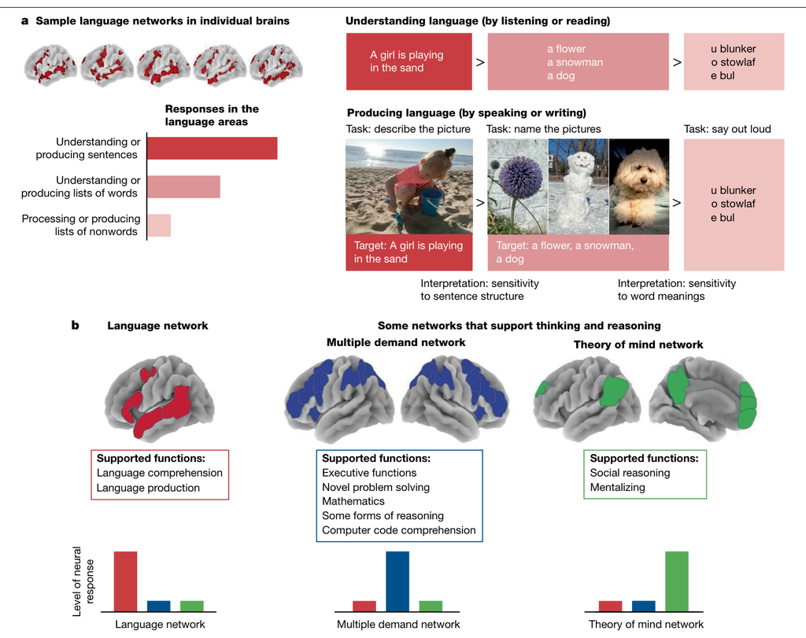

**图 1 | 语言网络及其与其他认知网络的关系。a**，人脑中的语言网络。语言网络支持在理解和产出中、跨各种模态的、与词汇提取和句法结构构建相关的计算，这表明该网络所操作的表征是抽象的。鉴于有人认为词语和句法结构的获取对思维的某些方面至关重要，这一脑网络是评估“语言用于思维”主张的明确靶标。左上，五名样本个体的语言网络。这些激活图是使用语言定位范式通过 fMRI 获得的，该范式将语言加工与知觉上相似的控制条件进行对比<sup>30</sup>。图中脑区在关键的语言加工条件下比在控制条件下表现出更多神经活动。左下，语言网络对理解或产出句子、无关联词列表和非词列表的反应模式示意图（例如通过 fMRI 测量）<sup>30,33,36,40,47</sup>。对句子的反应强于对词列表的反应，一般被视为表明该脑区参与了组合性（句法和语义）计算——这是加工句子而非词列表所必需的；对词列表的反应强于对非词列表的反应，被视为表明该脑区参与了词义提取——这是加工真词而非非词所必需的。右，脑成像实验中用于考察理解（上行）与产出（下行）中对句子、词列表和非词列表反应的样例刺激。**b**，语言与思维在人脑中是分离的。左，语言网络反应模式示意图（例如通过 fMRI 测量）。该网络对语言理解和产出反应强烈，但对需要思考和推理的非语言任务没有反应（例如参考文献 77）。语言网络的核心区域以红色示意性地显示在脑模板上（个体激活图样例见 **a**）。右，支持思考和推理的两个网络的反应模式示意图（例如通过 fMRI 测量）。多重需求网络（在脑模板上以蓝色示意）对多种高要求认知任务有反应，包括执行功能任务、新颖问题解决任务以及数学和逻辑推理，但对语言或社会推理没有反应（例如参考文献 76）。心理理论网络（在脑模板上以绿色示意）在社会推理过程中有反应，但对语言或高要求的执行功能任务没有反应（例如参考文献 86）。

**Fig. 1 | The language network and its relationship to other cognitive networks. a**, The language network in the human brain. The language network supports computations that are related to lexical access and syntactic structure building during both comprehension and production across modalities, which suggests that the representations that this network operates over are abstract. Given that access to words and syntactic structures has been argued to be critical for aspects of thinking, this brain network is a clear target for evaluating language-for-thought proposals. Top left, the language network in five sample individuals. These activation maps were obtained with fMRI using a language localizer paradigm, which contrasts language processing and a perceptually similar control condition<sup>30</sup>. The brain areas in these maps show more neural activity during the critical, language-processing condition compared with the control condition. Bottom left, a schematic representation of the response profile of the language network (for example, as measured by fMRI) to understanding or producing sentences, lists of unconnected words and lists of nonwords<sup>30,33,36,40,47</sup>. A stronger response to sentences than word lists is generally taken to suggest engagement of a brain region in combinatorial (syntactic and semantic) computations, a requirement for processing sentences but not lists of words; a stronger response to word lists than nonword lists is taken to suggest the engagement of a brain region in accessing word meanings, a requirement for processing real words but not nonwords. Right, sample stimuli used in brain imaging experiments to investigate responses to sentences, lists of words and lists of nonwords in comprehension (top row) versus production (bottom row). **b**, Language and thought are dissociated in the human brain. Left, a schematic representation of the response profile of the language network (for example, as measured by fMRI). This network responds strongly to language comprehension and production, but not to non-linguistic tasks that require thinking and reasoning (for example, ref. 77). The core regions of the language network are shown schematically in red on a brain template (sample individual activation maps are shown in **a**). Right, schematic representation of the response profiles of two networks that support thinking and reasoning (for example, as measured by fMRI). The multiple demand network (shown schematically in blue on a brain template) responds to diverse demanding cognitive tasks, including executive function tasks, novel problem-solving tasks, and mathematical and logical reasoning, but not to language or social reasoning (for example, ref. 76). The theory of mind network (shown schematically in green on a brain template) responds during social reasoning, but not to language or demanding executive function tasks (for example, ref. 86).

### 语言对于任何已测试的思维形式都不是必需的

### Language is not necessary for any tested forms of thought

推断脑–行为关联与分离的经典方法是考察脑损伤或脑疾病患者。如果语言能力介导我们进行某些形式思维的能力，那么语言障碍就应伴随这些方面思维与推理的困难。证据是明确无疑的——有许多个体存在严重的语言障碍（同时影响词汇和句法能力），却仍表现出从事多种形式思维的完好能力——他们能解决数学问题<sup>51,52</sup>，执行计划并遵循非言语指令<sup>53</sup>，从事多种形式的推理，包括形式逻辑推理、关于世界的因果推理和科学推理<sup>54–58</sup>，理解他人的信念或想法并进行语用推断<sup>53,56,59–62</sup>，在世界中导航<sup>63</sup>，以及对物体和事件做出语义判断<sup>64–70</sup>（图 1b）。

The classical approach for making inferences about brain–behaviour associations and dissociations is to examine individuals with brain damage or disorders. If linguistic ability mediates our ability to engage in certain forms of thought, then linguistic impairments should be associated with concomitant difficulties in those aspects of thinking and reasoning. The evidence is unequivocal—there are many cases of individuals with severe linguistic impairments, affecting both lexical and syntactic abilities, who nevertheless exhibit intact abilities to engage in many forms of thought—they can solve mathematical problems<sup>51,52</sup>, perform executive planning and follow non-verbal instructions<sup>53</sup>, engage in diverse forms of reasoning, including formal logical reasoning, causal reasoning about the world and scientific reasoning<sup>54–58</sup>, to understand what another person believes or thinks and perform pragmatic inference<sup>53,56,59–62</sup>, to navigate in the world<sup>63</sup>, and to make semantic judgements about objects and events<sup>64–70</sup> (Fig. 1b).

### 专栏 2 从语言神经生物学的经典模型到当前认识

### Box 2 From the classic model of the neurobiology of language to where we are now

许多教科书仍在使用语言神经基础的经典模型，该模型由 Wernicke 提出<sup>184</sup>，并经 Lichtheim 和 Geschwind 加以阐发和修订<sup>24,185</sup>。该模型由两个皮层区域组成——额下回皮层中的布洛卡区和颞上回后部皮层中的韦尼克区——它们被认为分别支持语言产出和语言理解，并由一条背侧纤维束（弓状束）相连（图 a）。多年来该模型受到不少批评<sup>27,186,187</sup>——但尽管不完整，经典模型正确地捕捉到了语言神经生物学的关键方面。我们认为，关于布洛卡区和韦尼克区的许多混淆，源于在实验设计和科学话语中频繁混淆*言语*（口语的形式）与*语言*（形式到意义映射的抽象系统），以及人类认知神经科学主要依赖脑区的解剖学定义而非功能定义。

Many textbooks continue to use the classic model of the neural basis of language, which was proposed by Wernicke<sup>184</sup> and elaborated and revised by Lichteim and Geschwind<sup>24,185</sup>. This model consists of two cortical areas—Broca’s area in the inferior frontal cortex and Wernicke’s area in the posterior superior temporal cortex—which are argued to support language production and comprehension, respectively, and which are connected by a dorsal fibre bundle (the arcuate fasciculus) (panel a). This model has received criticism over the years<sup>27,186,187</sup>—but, although incomplete, the classic model correctly captures key aspects of the neurobiology of language. We believe that much of the confusion about Broca’s and Wernicke’s areas has resulted from frequent conflation of *speech* (the form of spoken language) and *language* (the abstract system of form-to-meaning mappings) in experimental designs and scientific discourse, and predominant reliance in human cognitive neuroscience on anatomical rather than functional definitions of brain areas.

正如原始文献所述，布洛卡和韦尼克发现的脑区分别支持言语运动（发音）计划和言语感知。当前的神经科学证据有力支持在额下回皮层中存在一个发音选择性脑区<sup>188–192</sup>（图 b，红色），以及在颞上回中存在一个言语感知选择性脑区<sup>193–197</sup>（图 b，蓝色）。与语言网络脑区不同，这些脑区对语言意义不敏感，只对语言信号的表层属性敏感<sup>28</sup>。在这些脑区的名称中加入功能（例如“布洛卡发音计划区”和“韦尼克言语感知区”），并使用经过验证的“定位”范式将这些脑区与邻近的功能上不同的脑区区分开，很可能会推动进展并减少混淆<sup>28</sup>。

As described in the original sources, the brain areas that were discovered by Broca and Wernicke support speech motor (articulatory) planning and speech perception, respectively. Current neuroscientific evidence strongly supports the existence of an articulation-selective area in the inferior frontal cortex<sup>188–192</sup> (panel b, red) and of an area selective for speech perception in the superior temporal gyrus<sup>193–197</sup> (panel b, blue). In contrast to the language network areas, these areas are not sensitive to linguistic meaning, only to the surface properties of linguistic signals<sup>28</sup>. Adding function into these areas’ names (for example, ‘Broca’s articulatory planning area’ and ‘Wernicke’s speech perception area’) and using validated ‘localizer’ paradigms to separate these areas from nearby functionally distinct areas is likely to lead to progress and alleviate confusion<sup>28</sup>.

经典模型中缺少的是“高级语言脑区”，它们储存抽象的语言知识并支持理解和产出，如“人脑中的语言网络”一节所述（图 1a 及图 b，紫色）。对于早期语言神经生物学理论中缺少这些脑区，有一个直接的解释。关于脑–行为关系的早期证据来自脑损伤后选择性缺陷的报告。由于布洛卡区和韦尼克区相对局限且专门负责特定功能，它们受损更可能导致缺陷（因为没有其他脑区支持这些功能）。相比之下，高级语言网络分布在左侧颞叶和额叶皮层的广泛区域（图 1a 及图 b，紫色），不同语言区域表现出相似的功能特征<sup>28</sup>（其他观点见参考文献 27,198,199）。因此，与言语发音区和言语感知区不同，高级语言网络中可能没有哪个单独部分是语言功能所关键必需的。事实上，语言网络的局限性病灶并不会导致严重或持久的缺陷，尽管与言语感知区相邻的颞叶后部成分可能相对更为重要<sup>200</sup>。

Absent from the classic model are the ‘higher-level language areas’, which store abstract linguistic knowledge and support comprehension and production, as discussed in ‘The language network in the human brain’ (Fig. 1a and panel b, purple). There is a straightforward explanation for the absence of these areas from the early proposals of the neurobiology of language. The early evidence about brain–behaviour relationships came from reports of selective deficits following brain damage. Because Broca’s and Wernicke’s areas are relatively circumscribed and specialized for particular functions, their damage is more likely to lead to deficits (given that no other brain areas support these functions). By contrast, the higher-level language network is distributed across extensive portions of the left temporal and frontal cortex (Fig. 1a and panel b, purple), with different language regions exhibiting similar functional profiles<sup>28</sup> (alternative proposals are described in refs. 27,198,199). As a result, in contrast to speech articulation and speech perception areas, no individual part of the high-level language network may be critically needed for linguistic function. Indeed, circumscribed lesions to the language network do not lead to severe or long-lasting deficits, although the posterior temporal component, which is adjacent to the speech perception area, may be relatively more important<sup>200</sup>.

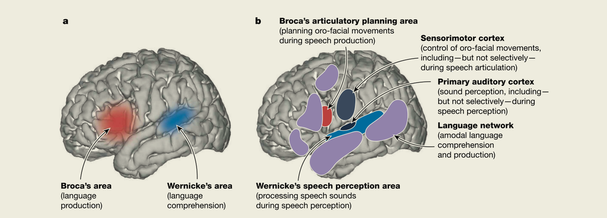

**经典模型与当前模型。| a**，语言神经生物学的经典模型。**b**，基于当前语言神经生物学知识的模型（其他观点见参考文献 27,198,199）。这一更新后的模型仍包括布洛卡（发音计划）区<sup>188–192</sup>和韦尼克（言语感知）区<sup>193–197</sup>，但另外还包括一组共同支持高级语言理解和产出的额叶和颞叶区域<sup>28</sup>（另见图 1a）。作为背景，我们还显示了初级听觉皮层（它很可能为韦尼克言语感知区提供输入）和感觉运动皮层（布洛卡发音计划区很可能向其提供输入）<sup>189,190</sup>。图中标注：布洛卡区（语言产出）；韦尼克区（语言理解）；布洛卡发音计划区（在言语产出中计划口面部运动）；感觉运动皮层（控制口面部运动，包括但不限于言语发音时）；初级听觉皮层（声音感知，包括但不限于言语感知时）；语言网络（非模态的语言理解与产出）；韦尼克言语感知区（在言语感知中加工语音）。

**Classic and current models. | a**, The classic model of the neurobiology of language. **b**, A model based on the current knowledge of neurobiology of language (alternative proposals are described in refs. 27,198,199). This updated model still includes Broca’s (articulatory planning) area<sup>188–192</sup> and Wernicke’s (speech perception) area<sup>193–197</sup>, but additionally includes a set of frontal and temporal areas that jointly support high-level language comprehension and production<sup>28</sup> (also see Fig. 1a). For context, we also show primary auditory cortex, which is likely to provide input to Wernicke’s (speech perception) area, and sensorimotor cortex, to which Broca’s (articulatory planning) area is likely to provide input<sup>189,190</sup>. Figure labels: Broca’s area (language production); Wernicke’s area (language comprehension); Broca’s articulatory planning area (planning oro-facial movements during speech production); Sensorimotor cortex (control of oro-facial movements, including—but not selectively—during speech articulation); Primary auditory cortex (sound perception, including—but not selectively—during speech perception); Language network (amodal language comprehension and production); Wernicke’s speech perception area (processing speech sounds during speech perception).

重要的是，在这些研究中，研究者仔细而系统地评估了个体的语言能力，以确保缺陷涉及的是语言能力（包括词汇和句法加工），而非较低层级的感知或运动能力<sup>71</sup>。这一系列证据既挑战了关于语言对思维重要性的一般性主张（专栏 1），也挑战了若干关于语言在特定类型思维中起关键作用的具体主张，包括数学推理<sup>72</sup>、跨领域信息整合<sup>9,73</sup>和分类<sup>74</sup>。尽管丧失了语言能力，一些严重失语症患者仍能完成所有已测试形式的思维与推理，这体现在他们在多种认知任务上的完好表现。他们只是无法将这些想法映射到语言表达上——无论是在语言产出中（无法通过语言向他人传达想法），还是在理解中（无法从他人的词句中提取意义）（图 1b）。当然，在某些脑损伤病例中，语言能力和（部分）思维能力可能同时受影响，但考虑到语言系统与其他高级认知系统在位置上的邻近<sup>75,76</sup>，这是可以预料的。

Importantly, in these studies, researchers carefully and systematically assessed the individuals’ linguistic abilities to ensure that the deficit concerns linguistic ability, including lexical and syntactic processing, and not the lower-level perceptual or motor abilities<sup>71</sup>. This body of evidence challenges both general claims about the importance of language for thought (Box 1), and a number of specific proposals about the critical role of language in particular kinds of thinking, including mathematical reasoning<sup>72</sup>, cross-domain information integration<sup>9,73</sup> and categorization<sup>74</sup>. Despite losing their linguistic ability, some individuals with severe aphasia are able to perform all tested forms of thinking and reasoning, as evidenced by their intact performance on diverse cognitive tasks. They simply cannot map those thoughts onto linguistic expressions, either in language production (they cannot convey their thoughts to others through language) or in understanding (they cannot extract meaning from others’ words and sentences) (Fig. 1b). Of course, in some cases of brain damage, both linguistic and (some) thinking abilities may be affected, but this is to be expected given the proximity of the language system to other high-level cognitive systems<sup>75,76</sup>.

神经影像学证据补充了来自脑损伤个体的证据。借助 fMRI 等工具，我们可以在完好、健康的大脑中识别语言脑区，然后在个体从事需要不同形式思维的任务时考察这些脑区的反应。在“人脑中的语言网络”一节中，我们为评估此类假说定义了一个明确的靶标：语言网络，即在我们理解和产出语言时普遍被调用的一组脑区<sup>28</sup>（图 1a）。研究者已考察了该网络对多种非语言输入和任务的反应，证据表明，在所有已测试的思维形式中，语言网络的所有区域基本都处于“沉默”状态，包括数学推理<sup>77–79</sup>、形式逻辑推理<sup>80,81</sup>、执行高要求的执行功能任务（如工作记忆或认知控制任务）<sup>77</sup>、理解计算机代码<sup>82,83</sup>、思考他人的心理状态<sup>84–86</sup>，以及对物体或事件做出语义判断<sup>69,70,87</sup>。相反，这些任务调用的是与语言网络不重叠的其他脑区（图 1b），尽管它们有时紧邻语言脑区<sup>75,76</sup>。未来的研究仍有可能发现某些会调用语言脑区、且对失语症患者构成挑战的思维任务，但迄今尚未发现此类任务。

Neuroimaging evidence complements the evidence from individuals with brain damage. Using tools such as fMRI, we can identify the language areas in intact, healthy brains and then examine the response in those areas while individuals engage in tasks that require different forms of thought. In ‘The language network in the human brain’, we defined a clear target for evaluating such hypotheses: the language network, a set of brain areas that are ubiquitously engaged when we understand and produce language<sup>28</sup> (Fig. 1a). Responses in this network to diverse non-linguistic inputs and tasks have been examined, and the evidence demonstrates that all regions of the language network are largely ‘silent’ during all tested forms of thought, including mathematical reasoning<sup>77–79</sup>, formal logical reasoning<sup>80,81</sup>, performing demanding executive function tasks such as working memory or cognitive control tasks<sup>77</sup>, understanding computer code<sup>82,83</sup>, thinking about others’ mental states<sup>84–86</sup>, and making semantic judgments about objects or events<sup>69,70,87</sup>. Instead, these tasks engage other brain areas that are non-overlapping with the language network (Fig. 1b), although they sometimes lie in close proximity to the language areas<sup>75,76</sup>. It remains possible that future work will uncover some thinking tasks that will engage language areas and that will prove challenging for patients with aphasia, but no such tasks have been found so far.

有些“语言用于思维”假说专门涉及认知发展（专栏 1）。根据这些假说，语言（或在某些理论中，更一般的符号表征）可能对某些类型或方式的思维的发展至关重要<sup>12,17,18,88,89</sup>。对这一观点的某些支持来自如下研究：教儿童或非人灵长类表示某些概念（例如“相同”这一概念）的词或符号，或以突出世界中与任务相关维度的方式分配标签（例如把较大的物体标为“爸爸”、较小的标为“宝宝”，以引起对物体大小的注意），可以使其在某些关系推理任务上获得成功<sup>18</sup>。另有研究者认为，训练幼儿掌握某些句法构式（例如补语从句）可使他们通过心理理论任务<sup>17,90,91</sup>。然而，存在怀疑的理由。第一，最近的证据表明，语言网络与支持思维和推理的系统之间的分离在幼儿身上就已存在<sup>92,93</sup>（专栏 3），这与“在早期发展阶段思维依赖语言资源”的可能性相矛盾。第二，一些在无法接触语言的环境中成长的儿童仍能进行复杂的推理。特别是，一些父母听力正常的聋童在成长过程中很少或根本接触不到语言，有时长达数年，因为他们听不到言语，而父母或照料者又不懂手语。缺乏语言接触会对认知的许多方面造成有害后果<sup>94,95</sup>，鉴于语言是了解世界的关键信息来源<sup>96,97</sup>，这是可以预料的。尽管如此，经历过语言剥夺的个体无疑表现出复杂认知功能的能力：他们仍能学习数学、进行关系推理、建立因果链，并获得丰富而精深的世界知识<sup>98,99</sup>（另见参考文献 100，其中提供了来自一例虐童案中语言剥夺的更具争议性的证据）。换言之，无法接触语言表征并不会使从事复杂的（包括符号性的）思维从根本上变得不可能，尽管推理的某些方面确实表现出延迟<sup>101,102</sup>。由此看来，在典型发展中，语言和推理是平行发展的（来自脑进化的一致证据见“人类与动物中的交流与思维”一节）。

Some language-for-thought hypotheses specifically concern cognitive development (Box 1). According to these hypotheses, language (or, in some accounts, symbolic representations more generally) may be critical for the development of certain kinds or ways of thinking<sup>12,17,18,88,89</sup>. Some support for this idea comes from studies in which teaching children or non-human primates words or symbols for certain concepts (for example, the concept ‘same’) or assigning labels in a way that highlights the task-relevant dimension of the world (for example, drawing attention to object size by labelling a bigger object ‘daddy’ and a smaller one ‘baby’) can lead to success on certain relational reasoning tasks<sup>18</sup>. Others have argued that training young children on certain syntactic constructions (for example, complement clauses) can result in their ability to pass theory of mind tasks<sup>17,90,91</sup>. However, reasons for skepticism exist. First, recent evidence suggests that the dissociation between the language network and systems that support thinking and reasoning is already present in young children<sup>92,93</sup> (Box 3), which contradicts the possibility that at an early developmental stage thinking relies on linguistic resources. And second, some children growing up with no access to language can nevertheless reason in complex ways. In particular, some deaf children who are born to hearing parents grow up with little or no exposure to language, sometimes for years, because they cannot hear speech and their parents or caregivers do not know sign language. Lack of access to language has harmful consequences for many aspects of cognition<sup>94,95</sup>, which is to be expected given that language provides a critical source of information for learning about the world<sup>96,97</sup>. Nevertheless, individuals who experience language deprivation unquestionably exhibit a capacity for complex cognitive function: they can still learn to do mathematics, to engage in relational reasoning, to build causal chains, and to acquire rich and sophisticated knowledge of the world<sup>98,99</sup> (also see ref. 100 for more controversial evidence from language deprivation in a case of child abuse). In other words, lack of access to linguistic representations does not make it fundamentally impossible to engage in complex—including symbolic—thought, although some aspects of reasoning do show delays<sup>101,102</sup>. Thus, it appears that in typical development, language and reasoning develop in parallel (see ‘Communication and thought in humans and animals’ for concordant evidence from brain evolution).

最后值得一提的是，前语言期婴儿<sup>103</sup>以及许多动物物种——包括非人灵长类<sup>104–108</sup>、鸦科鸟类<sup>109,110</sup>、大象<sup>111</sup>和头足类动物<sup>112,113</sup>——都表现出令人印象深刻的推理和问题解决能力，而且显然没有语言，这进一步使人质疑语言或类语言系统对于复杂思维的必要性<sup>114,115</sup>。

Finally, it is worth mentioning that pre-verbal infants<sup>103</sup> and many animal species—including non-human primates<sup>104–108</sup>, corvids<sup>109,110</sup>, elephants<sup>111</sup> and cephalopods<sup>112,113</sup>—exhibit impressive inferential and problem-solving abilities, apparently without language, further bringing into question the necessity of language or a language-like system for complex thinking<sup>114,115</sup>.

### 专栏 3 开放问题

### Box 3 Open questions

我们对人类语言能力和认知能力及二者关系的理解仍不完整。这里我们列出几个开放问题。

Our understanding of human linguistic and cognitive capacities and the relationships between them remains incomplete. Here we highlight a few open questions.

(1) 语言选择性脑网络所储存的*语言表征*的本质是什么？它在理解和产出中执行的*计算*是什么？人工智能的最新进展——擅长语言的神经网络模型的开发<sup>201</sup>——为语言研究者提供了一套强大的工具来探究语言加工的神经编码<sup>48,202–205</sup>（综述见参考文献 206）。这些工具与日益精密的神经记录方法<sup>207,208</sup>相结合，应能在未来几年推动我们对人类语言系统的理解。

(1) What is the nature of *linguistic representations* that the language-selective brain network stores and the *computations* that it performs during comprehension and production? Recent advances in artificial intelligence—the development of neural network models that excel at language<sup>201</sup>—have provided language researchers with a suite of powerful tools to probe the neural codes of linguistic processing<sup>48,202–205</sup> (reviewed in ref. 206). These tools, combined with the increasing sophistication of neural recording approaches<sup>207,208</sup>, should enable advances in our understanding of the human language system in the coming years.

(2) 我们的*思维*依赖于*符号表征*<sup>209–212</sup>、*亚符号或联结主义表征*<sup>213,214</sup>，还是二者的某种组合？介导抽象思维的表征如何从作为我们大脑的生物神经网络中产生<sup>215,216</sup>？是否有任何与思维相关的计算及其底层神经回路是人类所独有的，还是人类只是拥有更多的神经和认知资源<sup>163,173</sup>，从而带来更高的复杂程度？

(2) Does our *thinking* rely on *symbolic representations*<sup>209–212</sup>, *sub-symbolic or connectionist representations*<sup>213,214</sup>, or some combination of these? How do representations that mediate abstract thought arise from the biological neural networks that are our brains<sup>215,216</sup>? Are any thought-related computations and the underlying neural circuits distinctly human, or do humans simply have more neural and cognitive resources<sup>163,173</sup> that lead to greater sophistication?

(3) 随着儿童学习语言，语言网络是如何*发展*的？到四岁时已对语言具有选择性的脑区<sup>92,93</sup>在语言习得之前支持什么认知功能？尽管已有许多研究考察了新生儿和婴儿大脑对言语的反应<sup>217–219</sup>，但在生命第一年的后半段以及学步期（6 个月至 3 岁）——即儿童开始把词与意义联系起来并以交流方式使用语言的时期——大脑中发生的功能变化仍不清楚，因为在这一年龄段使用 fMRI 等空间精确的脑成像方法进行实验颇具挑战。

(3) How does the language network *develop* as children learn language? What cognitive functions do brain areas that are selective for language by age four<sup>92,93</sup> support before language is acquired? Although a number of studies have investigated responses to speech in newborn and infant brains<sup>217–219</sup>, the functional changes that happen in the brain during the second half of the first year of life and during toddlerhood (age 6 months to 3 years), when children begin to link words to meanings and to use language communicatively, remain unknown because experimentation with spatially precise brain imaging approaches such as fMRI is challenging at this age.

### 完好的语言并不意味着完好的思维

### Intact language does not imply intact thought

上文讨论的证据表明，迄今测试过的所有类型的思维在没有语言的情况下都是可能的。接下来，我们讨论语言与思维双重分离的另一面：与“语言介导思维”的观点相反，完好的语言系统似乎并不意味着完好的推理能力。来自发育性和获得性脑疾病的证据都表明，即使语言能力基本完好，也可能存在智力损害。例如，若干遗传疾病以不同程度的智力障碍为特征（唐氏综合征和威廉姆斯综合征等），然而这些疾病患者的语言能力似乎接近典型水平。即便观察到细微的语言缺陷，加工词义和构建语言结构的基础能力——即“语言用于思维”假说中所涉及的能力——仍是完好的<sup>116–118</sup>。某些神经精神疾病（如精神分裂症）会影响思考和推理能力，但同样不累及语言<sup>119</sup>。最后，许多获得性脑损伤个体在推理和问题解决上存在困难，却似乎完全掌握着自己的语言能力<sup>58</sup>。换言之，拥有完好的语言系统并不会“免费”附带思维能力：在语言完好的情况下，思维能力也可能受损（来自大语言模型的相关论证见参考文献 120）。

The evidence discussed above suggests that all types of thought tested to date are possible without language. Next, we discuss the other side of the double dissociation between language and thought: contrary to the view that language mediates thinking, an intact language system does not appear to entail intact reasoning abilities. Evidence from both developmental and acquired brain disorders suggests that intellectual impairments can be present even when linguistic abilities are largely intact. For example, several genetic disorders are characterized by varying degrees of intellectual disability (Down syndrome and Williams syndrome, among others), yet the linguistic abilities of people with these disorders appear to be close to typical. Even if subtle linguistic deficits are observed, the foundational capacities for processing word meanings and linguistic structure building—the capacities that figure in the language-for-thought hypotheses—are intact<sup>116–118</sup>. Some neuropsychiatric disorders, such as schizophrenia, affect the ability to think and reason, but again spare language<sup>119</sup>. Finally, many individuals with acquired brain damage exhibit difficulties in reasoning and problem solving but appear to have full command of their linguistic abilities<sup>58</sup>. In other words, having an intact language system does not bring with it ‘for free’ an ability to think: thinking capacities can be impaired in the presence of intact language (see ref. 120 for related arguments from large language models).

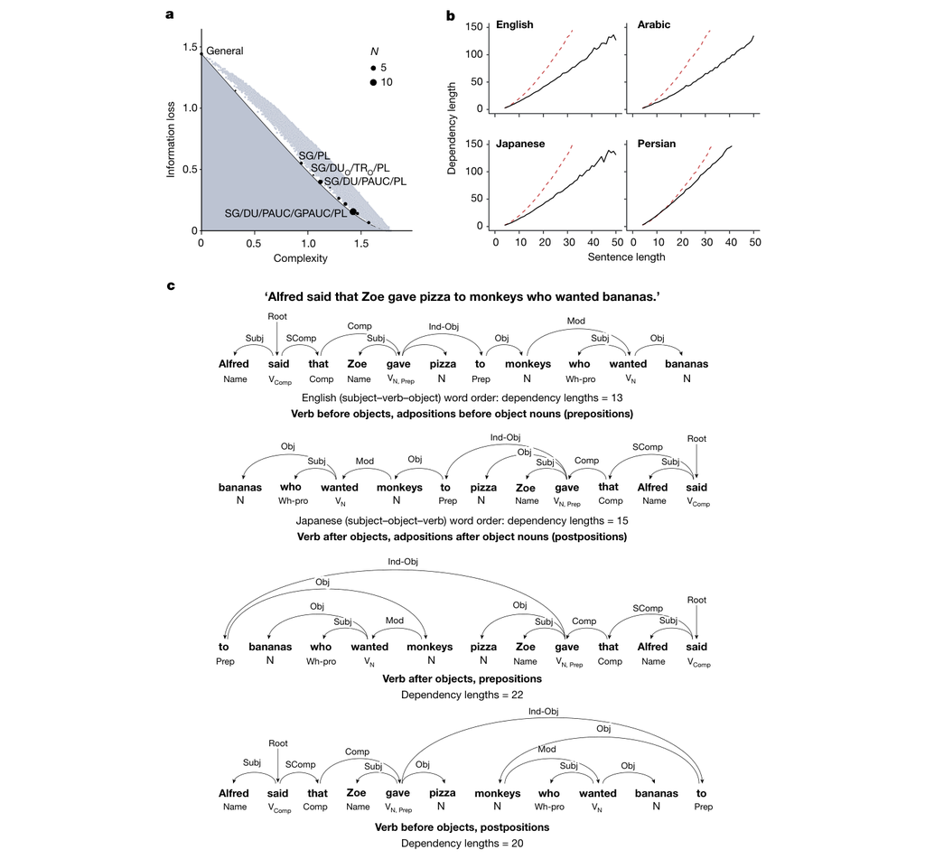

**图 2 | 人类语言受交流压力塑造。a**，在许多语义领域中，词语在复杂度与信息量之间进行权衡。这一模式正如高效交流系统所预测的那样（此处以语法数标记领域为例<sup>135</sup>）。已证实存在的标记系统（黑点；大小对应拥有该系统的语言数量 *N*）和未见于语言的系统（灰点）绘制在所有可能语法系统构成的空间中。实现最优权衡的系统位于帕累托前沿（实线）上；实线下方的阴影区域表示不可能实现的权衡。DU，双数；GPAUC，大寡数（“一堆”）；PAUC，寡数（“几个”）；PL，复数；SG，单数；TR，三数。可选值以下标“o”表示。**b**，语言在跨语言范围内最小化句法依存长度<sup>146</sup>。基于大型语料库分析，四种类型学上各异的语言中 1 至 50 词句子的实测平均依存长度（各图中的黑线）。对于语料库中的每个句子，按 **c** 所示将所有依存长度相加，得到单一数值。红色虚线表示随机基线：先打乱词语顺序（保留层级依存结构且不允许依存交叉），再重新计算依存长度<sup>146</sup>。所有曲线均以广义加性模型拟合。在各语言中（37 种语言的数据见参考文献 146），实测依存长度均低于随机基线，表明语言的演化使依存关系变短，这大概是为了便于产出和理解。**c**，不同语言中句法依存长度最小化的例子。第一行，主–谓–宾语序语言（例如英语）的句法依存结构。动词出现在宾语名词之前；介词出现在宾语名词之前。在此例及其他例子中，每个词下方标出其句法范畴，词与词之间的关系以有向弧表示；关系类型标在每条弧上方。句子的总依存长度为所有依存距离之和——例如，“Alfred”与“said”之间的依存长度为 1；对于非相邻词之间的依存，依存长度为中间词数加 1。对于该句，共有 7 个长度为 1 的局部依存和 3 个长度为 2 的依存，句子总依存长度为 7 + 6 = 13。第二行，主–宾–谓语序语言（例如日语）的句法依存结构。动词出现在宾语名词之后；介词（后置词）出现在宾语名词之后。两种在自然语言中很少出现的语序，推测是因为它们会引入长距离依存：第三行中，动词出现在宾语名词之后，而介词出现在宾语名词之前；第四行中，动词出现在宾语名词之前，而介词（后置词）出现在宾语名词之后。Comp，标句词；Ind-Obj，间接宾语；Mod，修饰语；N，名词；Obj，宾语；root，句子的根；SComp，句子补语；Subj，主语；V<sub>Comp</sub>，带标句词论元的动词；V<sub>N</sub>，带名词论元的动词；V<sub>N, Prep</sub>，带名词和介词论元的动词；Prep，介词；Wh-pro，wh 代词（例如“who”）。

**Fig. 2 | Human languages are shaped by communicative pressures. a**, Words across many semantic domains trade-off between complexity and informativeness. This pattern is as predicted for efficient communication systems (here, shown for the domain of grammatical number markers<sup>135</sup>). Attested inventories (black dots; sizes correspond to the number of languages with a given inventory (*N*)) and unattested systems (grey dots) are plotted in the space of all possible grammatical systems. Systems that achieve optimal trade-offs lie along the Pareto frontier (solid line); the shaded region below the line shows trade-offs that are impossible to achieve. DU, dual; GPAUC, greater paucal (a bunch); PAUC, paucal (a few); PL, plural; SG, singular; TR, trial. Optional values are shown with the subscript ‘o’. **b**, Languages minimize syntactic dependency lengths cross-linguistically<sup>146</sup>. Observed average dependency lengths (black lines in each graph) for sentences of 1 to 50 words across four typologically diverse languages, based on analyses of large language corpora. For each sentence in the corpus, a single value was computed by summing the lengths of all dependencies as shown in **c**. The red dashed line shows a random baseline created by first scrambling the words, preserving the hierarchical dependency structure and disallowing crossing dependencies, and then recomputing dependency lengths<sup>146</sup>. All lines are fitted using a generalized additive model. Across languages (ref. 146 for data from 37 languages), the observed dependency lengths fall below the random baseline, suggesting that languages evolve to make dependencies shorter, presumably to facilitate production and comprehension. **c**, Examples of minimization of syntactic dependency lengths in different languages. Top row, syntactic dependency structure for a subject–verb–object word order language (for example, English). Verbs appear before object nouns; prepositions appear before object nouns. Here and in the other examples, the syntactic category of a word is shown under each word and the relationships between words are shown with directed arcs; the type of the relationship is marked above each arc. The total dependency length of a sentence is the sum of all dependency distances—for example, the dependency between ‘Alfred’ and ‘said’ is 1; for dependencies between non-adjacent words, the dependency length is the number of intervening words plus 1. For this sentence, there are 7 local dependencies of length 1 and 3 dependencies of length 2, for a total sentence dependency length of 7 + 6 = 13. Second row, syntactic dependency structure for a subject–object–verb word order language (for example, Japanese). Verbs appear after object nouns; prepositions (postpositions) appear after object nouns. Two word orders that rarely occur in natural languages, putatively because they introduce long-distance dependencies: in the third row, verbs appear after object nouns, and prepositions appear before object nouns; in the fourth row, verbs appear before object nouns, and prepositions (postpositions) appear after object nouns. Comp, complementizer; Ind-Obj, indirect object; Mod, modifier; N, noun; Obj, object; root, the root of the sentence; SComp, sentence complement; Subj, subject; V<sub>Comp</sub>, verb taking a complementizer argument; V<sub>N</sub>, verb taking a noun argument; V<sub>N, Prep</sub>, verb taking a noun and a preposition argument; Prep, preposition; Wh-pro, wh-pronoun (for example, ‘who’).

## 语言是一种高效的交流编码

## Language is an efficient communication code

在回顾了反对语言在思维中起作用的证据之后，我们接下来讨论交流力量塑造了语言形式的证据<sup>2–7</sup>。一种高效的交流编码应当易于产出和理解，同时对噪声（环境噪声或因加工机制不完善而产生的噪声）具有鲁棒性<sup>21</sup>，并且必须能为人所习得。正如我们接下来将讨论的，人类语言——无论是口语还是手语——都表现出所有这些特性，而且这些特性体现在语言结构的各个层面，包括语音、词和句法。

Having reviewed the evidence against the role of language in thought, we next discuss evidence that communicative forces have shaped the form that language takes<sup>2–7</sup>. An efficient communication code should be easy to produce and understand, while being robust to noise<sup>21</sup> (environmental or resulting from imperfect processing mechanisms), and it must be learnable by people. As we discuss next, human languages—both spoken and signed—exhibit all these properties, and these properties manifest at all levels of linguistic structure, including sounds, words and syntax.

我们承认，这些特性中有一些并非“语言用于交流”观点所独有的预测。然而，长期以来，一些“语言用于思维”假说的支持者一直把语言据称缺乏交流特征作为反对语言交流功能的证据<sup>121</sup>，因此有必要总结现已十分丰富的、表明这些特征在跨语言中稳健存在的证据。此外，某些交流特征在“语言主要用于内部思维”的观点下难以解释。

We acknowledge that some of these properties are not uniquely predicted by the language-for-communication view. However, the supposed absence of communicative features of language has long been used by some advocates of the language-for-thought hypothesis as evidence against the communicative function of language<sup>121</sup>, so it is important to summarize the now abundant evidence for the robust presence of these features cross-linguistically. Moreover, some of the communicative features are difficult to explain under the view that language is used primarily for internal thought.

从语言结构的最低层级开始，一种语言的*语音*在语音空间中是分散分布的<sup>122,123</sup>，这使它们能够以抗噪声干扰的方式承载信息，并促进感知和理解。语言的语音库似乎还受到影响不同音类发音难易的因素塑造，包括物理环境<sup>124</sup>以及与饮食相关的发音器官解剖结构变化<sup>125</sup>。

Starting from the lowest level of linguistic structure, the *sounds* of a language are spread out in phonetic space<sup>122,123</sup>, which enables them to carry information in a way that is robust to corruption from noise and facilitates perception and comprehension. Sound repertoires of languages appear to also be shaped by factors that affect articulatory ease for different sound classes, including physical environments<sup>124</sup> and diet-related changes in the anatomy of the articulatory apparatus<sup>125</sup>.

就*词形*而言，语言倾向于重复使用简短高效的词和词内语音序列<sup>126</sup>。此外，高频词和低信息量的词往往较短<sup>127</sup>。这些特性使得在产出和理解中提取词语更容易（高频词更容易从记忆中提取），也使发音更省力（短词耗能更少，重复出现的语音序列可以作为组块存储在运动记忆中，从而降低发音计划成本<sup>128</sup>）。

With respect to *word forms*, languages preferentially re-use short and efficient words and within-word sound sequences<sup>126</sup>. Moreover, frequent and low-information words tend to be short<sup>127</sup>. These properties enable ease of word retrieval in production and comprehension (frequent words are easier to access from memory) and for articulatory ease (short words are less energy-costly, and repeated sound sequences can be stored as chunks in motor memory, reducing articulatory planning costs<sup>128</sup>).

在*词义*方面，词语通过在复杂度（习得或表征意义的成本）与信息量（词语选取其意义的精确和无歧义程度）之间进行权衡来优化交流效率。亲属称谓就是一个例子<sup>129</sup>：不同语言在由“简单意义与信息丰富意义”之间权衡所界定的最优前沿上选择了不同的解决方案（例如，能指出家谱中唯一成员的词，如“外祖母”）。自然语言所具有的这种效率意味着，通常不可能在不减少所传达信息的情况下使一种真实语言的亲属称谓系统大幅简化，反之亦然。颜色词<sup>130,131</sup>、季节词<sup>132</sup>以及封闭类词和语法标记<sup>133–136</sup>也有类似的报告（图 2a）。词汇系统还表现出适应特定交流需求的特征，会更密集地覆盖特定社群所需的概念空间部分<sup>137,138</sup>。

In terms of *word meanings*, words optimize communicative efficiency through a trade-off between complexity (the cost of acquiring or representing the meanings) and informativeness (how precisely and unambiguously the words select their meanings). One example is kinship terms<sup>129</sup>: languages choose different solutions along the optimal frontier defined by the trade-off between having simple versus informative meanings (for example, words that pick out unique members of a family tree, such ‘maternal grandmother’). The efficiency that characterizes natural languages means that it is typically not possible to make a real language’s kinship system much simpler without having it convey less information, or vice versa. Similar results have been reported for colour terms<sup>130,131</sup> and season words<sup>132</sup>, and closed-class words and grammatical markers<sup>133–136</sup> (Fig. 2a). Lexical systems also show hallmarks of adaptation to specific communicative needs, more densely covering the parts of a conceptual space that a given community needs<sup>137,138</sup>.

*句法*是在“语言是否为高效交流而优化”的讨论中争议最大的语言成分。句法规定了词如何组合以表达海量的意义——即“有限手段的无限运用”<sup>139</sup>。句法的决定性特性——层级性与组合性——很可能是上文在词义部分提到的同样压力的结果：简洁性压力（对可习得性至关重要）和表达力压力（对有效交流至关重要）<sup>5,140–142</sup>。此外，世界语言中的各种句法模式也可以通过结合交流压力与认知压力来解释。一个典型例子是语言倾向于最小化词与词之间依存关系的长度。在任何给定的句子中，词语都按照语法规则组合起来，形成更大的意义。例如，在句子“Lana ate five apples”（拉娜吃了五个苹果）中，“five”和“apples”之间存在依存关系，但“Lana”和“five”之间没有联系，因为这两个词在意义上并不直接相关。距离更长的连接（中间隔着更多词的连接）会增加产出和理解的难度，这在行为学测量<sup>143,144</sup>和脑成像<sup>39,45</sup>中都得到了证实。很可能正是由于这种认知成本，语言通过最小化依存长度而演化得在加工（即使用）上更为高效<sup>145,146</sup>（图 2b、c）。语法中保持依存关系局部化的这种功能压力解释了词序中若干普遍倾向<sup>147,148</sup>。

*Syntax* is the component of language that has been the most controversial in the discussions about whether languages are optimized for efficient communication. Syntax specifies how words combine to enable the expression of a vast number of meanings—the ‘infinite use of finite means’<sup>139</sup>. The defining properties of syntax—hierarchy and composition—are probably the result of the very same pressures mentioned in the context of word meanings above: the pressure for simplicity (critical for learnability) and the pressure for expressiveness (critical for effective communication)<sup>5,140–142</sup>. Moreover, various syntactic patterns in the world’s languages can also be explained by combining communicative and cognitive pressures. A prime example is the tendency of languages to minimize the lengths of dependencies between words. In any given sentence, words are assembled—according to the rules of the grammar—to form a larger meaning. For example, the sentence ‘Lana ate five apples’, has a dependency between ‘five’ and ‘apples’, but there is no link between ‘Lana’ and ‘five’ because those words are not directly related in the meaning. Longer-distance connections (connections with more intervening words) increase difficulty of production and comprehension, as measured behaviourally<sup>143,144</sup> or with brain imaging<sup>39,45</sup>. Plausibly owing to this cognitive cost, languages have evolved to become more efficient for processing—that is, use—by minimizing dependency lengths<sup>145,146</sup> (Fig. 2b,c). This functional pressure in a grammar to keep dependencies local explains several universal tendencies in word orders<sup>147,148</sup>.

其他例子涉及句子中基本成分——主语（大致为施事）、动词和宾语（大致为动作的受事）——的顺序，用以传达复杂意义。主–宾–谓语序是世界语言中最常见的语序（约 47% 的语言，例如日语、波斯语和印地语），它似乎是一种认知上自然的默认语序：说不同语言的人在用手势表达事件意义时都使用这一顺序<sup>149</sup>，新兴手语也采用这一语序<sup>150,151</sup>。Gibson 等人<sup>152</sup>进一步为一些语言从默认的主–宾–谓语序转向第二常见的主–谓–宾语序（约 41% 的语言，例如英语、乌克兰语和汉语普通话）提供了交流方面的解释。具体而言，在主–谓–宾语序中，当交流中出现信息丢失时，听者可以利用位置线索——某个名词出现在动词之前还是之后——来重建“谁对谁做了什么”<sup>153,154</sup>（参考文献 155–157 描述了源于类似压力的其他词序概括）。

Other examples concern the order of basic elements—the subject (the agent, roughly), verb and object (the patient of the action, roughly)—within a sentence to convey complex meanings. The subject–object–verb order, which is the most common across the world’s languages (approximately 47% of languages—for example, Japanese, Persian and Hindi), appears to be a cognitively natural default: speakers of diverse languages use this order when gesturing event meanings<sup>149</sup>, and emergent sign languages have this order<sup>150,151</sup>. Gibson et al.<sup>152</sup> have further offered a communicative explanation for the shift of some languages from the default (subject–object–verb) order to the second most common order, subject–verb–object (approximately 41% of languages—for example, English, Ukrainian and Mandarin). In particular, in the subject–verb–object order, the listener can use positional cues—whether a given noun appears before or after the verb—to reconstruct who is doing what to whom in the presence of information loss during communication<sup>153,154</sup> (refs. 155–157 describe other word-order generalizations that follow from similar pressures).

反对“语言是作为交流系统而演化”这一观点的一个常见论据是歧义的普遍存在：大多数词有多种意义，许多句子（尤其是较长的句子）有多种可能的依存结构。例如，Chomsky 长期以来认为，歧义的存在意味着语言主要用于思维而非交流，因为有歧义的信号会妨碍交流<sup>121</sup>。然而，在“语言用于思维”的观点下，人类语言中存在歧义实际上并不在预期之中，因为我们的思想似乎并不含糊。相反，歧义的存在是语言交流理论的自然预测。也就是说，可以从数学上证明歧义在交流上是有用的：它不仅允许说话者省略听者已知的信息（例如从语境中已知的信息），还使简短、易于产出的语言形式得以重复使用<sup>158</sup>。一个不允许任何歧义的系统将需要比人类语言系统大得多的词库和语法，而且即便要传达简单的意义，也需要使用很长的词和句子。例如，一种为消除歧义而构建的人造语言<sup>159</sup>被证明过于复杂，以至于人类无法习得，并且已经历多轮修订以提高可学性。此外，有观点认为，具有多个相关义项的词（例如“water”既可作名词表示饮用的水，也可作动词表示浇水）有助于学习，因为习得一个意义会有助于习得相关的另一个意义<sup>160</sup>。由此看来，支持多重形式–意义映射的能力很可能有助于维持丰富的词库。

One common argument against the idea that language has evolved as a communication system is the prevalence of ambiguity: most words have multiple meanings, and many (especially longer) sentences have many possible dependency structures. Chomsky, for instance, has long argued that the existence of ambiguity implies that language is used primarily for thought rather than communication, because ambiguous signals would impede communication<sup>121</sup>. However, the existence of ambiguity in human language is actually not expected under the language-for-thought view, given that our thoughts do not seem ambiguous. By contrast, the existence of ambiguity in language is a natural prediction of communicative accounts of language. That is, ambiguity can be mathematically shown to be communicatively useful: not only does it allow speakers to leave out information that listeners already know (for example, from the context), but it enables the re-use of short, easy-to-produce linguistic forms<sup>158</sup>. A system that allows no ambiguity would require a much bigger lexicon and grammar than those of human linguistic systems, and such a system would need to use long words and sentences to convey even simple meanings. For example, an artificial language that was constructed to remove ambiguity<sup>159</sup> proved to be so complicated as to be unlearnable by humans and has been undergoing rounds of revision to allow for learnability. Moreover, the existence of words with multiple related senses (such as ‘water’ used as a drink and as a verb) has been argued to support learning, since acquisition of one meaning will help with acquisition of a related one<sup>160</sup>. In this way, the capacity for multiple form–meaning mappings is likely to be useful for maintaining a rich lexicon.

我们承认，人类语言的某些特性也可能有非交流性的解释。例如，语言的组合性可能只是反映了思维中、甚至较低层级的感知和运动系统中预先存在的组合性<sup>161</sup>——不过这一观点仍与“语言用于思维”假说相悖，因为其方向是反过来的。

We acknowledge that some of these properties of human languages may also have non-communicative explanations. For example, compositionality in language may simply reflect pre-existing compositionality in thought, or even in lower-level, perceptual and motor systems<sup>161</sup>—although this idea is still contrary to the language-for-thought hypothesis, as the directionality is reversed.

## 人类与动物中的交流与思维

## Communication and thought in humans and animals

在各个物种中，与同类的互动都需要一个交流系统——即感知和发出信号的机制，以及信号–意义关联的储存。人类的交流系统无疑是复杂的，但语言是否赋予了我们一种新的推理形式（专栏 1），还是语言只是反映了人类思想独立存在的复杂精妙？在这篇观点文章中，我们在前人理论的基础上，结合过去二十年的证据，论证了语言似乎并不是迄今测试过的任何形式思维所必需的，而且语言对思维也不是充分的。此外，基于自然语言的许多特征似乎都为高效信息传递而优化这一证据，我们论证了交流是语言的首要功能。

Across species, interactions with conspecifics require a communication system—that is, mechanisms for perceiving and emitting signals and a store of signal-to-meaning associations. The communication system of humans is unquestionably complex, but did language endow us with a new form of reasoning (Box 1), or does language simply reflect the independent sophistication of human thoughts? In this Perspective, building on prior theorizing and bringing in evidence from the past two decades, we have argued that language appears to not be necessary for any forms of thought tested so far, and that language is not sufficient for thought. Furthermore, on the basis of the evidence that many features of natural languages appear to be optimized for efficient information transfer, we have argued for communication being the primary function of language.

“语言只是一个交流系统”的观点与人类进化的连续性观点相一致<sup>162,163</sup>。按照这一观点，人类语言的特性——包括其复杂性——可能源于语言演化所处的多方面环境：在这一环境中，该系统必须有用（能够表达人类心智的内部内容）且可习得，而人类应能够以既有认知和神经系统所特有的优势与局限来加工语言。与之相对的另一种观点——语言是思维的基质——则意味着我们这一物种与其他物种之间存在截然的不连续性。这种观点把语言（或许是先天的）置于中心，视其为变化的机制，以及赋予人类一种用于心理计算的新型表征格式的机制。

The view that language is simply a communication system aligns with a continuity view of human evolution<sup>162,163</sup>. In this view, the properties of human language—including its complexity—may result from the multifaceted landscape in which it has evolved, where the system must be useful (able to express the internal contents of the human mind) and learnable, and humans should be able to process language with the idiosyncratic strengths and limitations of pre-existing cognitive and neural systems. The contrasting alternative—that language is the substrate for thinking—implies a sharp discontinuity between our species and others. This alternative view centres language—perhaps innately—as the mechanism of change, and the mechanism that endowed humans with a novel representational format for mental computations.

为什么语言与思维之间的密切关系对许多人具有直觉上的吸引力？有些人执着于“人类在动物界中具有优越性”的观念（即人类与其他动物存在质的差异而不仅是量的差异<sup>164</sup>），尽管科学证据表明人类与非人动物之间存在很强的生物学相似性<sup>165,166</sup>。另一个原因可能与在解释人类与非人动物差异时追求简约有关（其他原因见补充信息）。具体而言，人类在交流系统以及思想和认知的复杂精妙程度上都不同于其他动物。简约的解释倾向于单一因素的说明——例如，人类进化出了语言，而认知的变化只是其结果。然而，来自人脑进化的证据反而表明，多个认知系统的复杂程度是平行提高的。

Why does an intimate relationship between language and thought have an intuitive appeal to many? Some are attached to the idea that humans are superior in the animal kingdom (that is, they differ qualitatively, not just quantitatively, from other animals<sup>164</sup>), even though scientific evidence suggests strong biological similarities between humans and non-human animals<sup>165,166</sup>. Another reason may be linked to the desire for parsimony in explaining differences between humans and non-human animals (additional reasons are provided in Supplementary Information). In particular, humans differ from other animals in the sophistication of their communication system as well as their thoughts and cognition. A parsimonious account favours a single-factor explanation—for instance, humans evolved language, and the change in cognition was simply a consequence of this. However, evidence from human brain evolution instead suggests parallel increases in the sophistication of multiple cognitive systems.

与其他动物（包括非人灵长类）的大脑相比，联合皮层——承载着超越感知和运动控制的心理过程——在人脑中显著且不成比例地扩张了<sup>167</sup>。联合皮层跨越额叶、颞叶和顶叶，在人类中由多个大规模网络组成——即共同支持认知某一方面的脑区集合<sup>75</sup>。语言网络<sup>28</sup>只是这些网络之一。在刻画支持人类认知能力的若干其他网络方面已取得重大进展，包括那些支持“语言对于思维既不必要也不充分”一节中所讨论的非语言任务的网络。例如，有时被称为“多重需求”网络的网络支持多种目标导向行为，包括新颖问题的解决，该网络受损会导致流体智力受损<sup>168</sup>（图 1b）。数学和逻辑推理以及计算机代码的加工也依赖多重需求网络<sup>78–83</sup>。其他此类网络包括支持社会推理（包括心理化，即思考他人的想法）的“心理理论”网络<sup>169</sup>（图 1b），以及“默认”网络——其功能仍有争论，有人将其区域与向过去或未来的情景投射联系起来<sup>170</sup>，另一些人则将其与空间认知和推理联系起来<sup>171</sup>。至少其中某些网络在非人动物大脑中有同源结构<sup>172</sup>——跨物种功能架构的对应关系是神经科学中一项正在进行的工作。

Relative to the brains of other animals, including non-human primates, the association cortex—which houses mental processes above and beyond perception and motor control—has expanded substantially and disproportionately in the human brain<sup>167</sup>. The association cortex spans frontal, temporal and parietal lobes and, in humans, comprises multiple large-scale networks—ensembles of brain areas that jointly support some aspect of cognition<sup>75</sup>. The language network<sup>28</sup> is just one of these networks. Significant progress has been made in characterizing several other networks that support human cognitive abilities, including those underlying the non-linguistic tasks discussed in ‘Language is not necessary or sufficient for thought’. For example, the network sometimes referred to as the ‘multiple demand’ network, supports diverse goal-directed behaviours, including novel problem solving, and damage of this network leads to impairments in fluid intelligence<sup>168</sup> (Fig. 1b). Mathematical and logical reasoning and the processing of computer code also draw on the multiple demand network<sup>78–83</sup>. Other such networks include the ‘theory of mind’ network, which supports social reasoning, including mentalizing or thinking about others’ thoughts<sup>169</sup> (Fig. 1b) and the ‘default’ network, whose functions remain debated, with some linking its regions to episodic projection into the past or future<sup>170</sup> and others linking them to spatial cognition and reasoning<sup>171</sup>. At least some of the networks have homologues in non-human animal brains<sup>172</sup>—the correspondences in functional architecture across species is an ongoing effort in neuroscience.

然而重要的是，在人类进化过程中有多个脑网络发生了扩张，而这种扩张与多种认知能力的提升相关联<sup>173</sup>。这种扩张究竟是真正平行进行的，还是某一个网络的出现或扩张关键地驱动了其他网络的扩张，目前尚不清楚；但前一种可能性或许更合理，因为多种认知能力很可能都提高了生存概率——包括社会复杂性（能够对他人心智建模）、推断世界中因果结构的能力、灵活的问题解决和为未来做计划的能力，以及更好的交流能力。无论现代人类大脑中不同认知网络扩张的确切时间线和顺序如何，语言网络——支持我们与同类交流的能力——与支持我们思考和推理能力的网络截然不同，这使得“语言介导思维”的观点不太可能成立。

Importantly, however, multiple brain networks have expanded over the course of human evolution, and this expansion was associated with increases in diverse cognitive abilities<sup>173</sup>. Whether this expansion proceeded in a truly parallel fashion, or whether the emergence or expansion of one network critically drove the expansion of other networks is not known, but the former possibility is perhaps more plausible given that diverse cognitive abilities probably increased the probability of survival—including social sophistication (being able to model the minds of others), the ability to infer causal structures in the world, flexible problem solving and planning for the future, and better communicative ability. Regardless of the exact timeline and order of the expansion of different cognitive networks in the brains of modern humans, the language network—which supports our ability to communicate with conspecifics—is sharply distinct from the networks that support our abilities to think and reason, which makes the idea that language mediates thinking unlikely.

## 结论

## Conclusions

总之，我们回顾了过去二十年的研究工作，这些工作有助于阐明语言在现代人类中的功能及其在人类认知中的作用。来自失语症研究的证据表明，所有已测试形式的思维在没有语言的情况下都是可能的；fMRI 证据表明，从事多种形式的思维和推理并不会调用语言网络——即在语言理解和产出过程中表征和加工词义与句法结构的一组脑区。此外，完好的语言能力并不意味着完好的思维能力。综合来看，这些证据表明语言不太可能是任何形式思维的关键基质。尽管接触词语、句法结构或非语言符号可以促进某些认知任务的表现（专栏 1），但语言与思维和推理是双重分离的（关于语言表征和介导思维的心理表征之本质的开放问题，参见专栏 3）。

In sum, we have reviewed work from the past two decades that has helped to clarify the function of language in modern humans and its role in human cognition. Evidence from aphasia research suggests that all tested forms of thought are possible in the absence of language, and fMRI evidence suggests that engaging in diverse forms of thinking and reasoning does not recruit the language network—a set of brain areas that represent and process word meanings and syntactic structure during language comprehension and production. Moreover, intact linguistic abilities do not entail intact thinking abilities. Together, this evidence suggests that language is unlikely to be a critical substrate for any form of thought. Although access to words, syntactic structures or non-linguistic symbols can facilitate performance on certain cognitive tasks (Box 1), language is doubly dissociated from thinking and reasoning (compare with Box 3 for open questions about the nature of linguistic and thought-mediating mental representations).

我们还回顾了一系列研究，它们表明人类语言的多种特性使其易于产出、易于学习和理解、简洁高效且对噪声具有鲁棒性。其中许多跨语言倾向——包括最小化依存长度的倾向、对特定词序的偏好以及歧义的普遍存在——在“语言用于内部思维”的观点下、且不诉诸语言如何被使用和加工的情况下，是难以解释的。

We have also reviewed a body of work that has shown that diverse properties of human languages render them easy to produce, easy to learn and understand, concise and efficient for use, and robust to noise. Many of these cross-linguistic tendencies—including the tendency to minimize dependency lengths, the preferences for particular word orders, and the prevalence of ambiguity—are difficult to account for under the view that language is used for internal thought and without appealing to how language is used and processed.

综合考虑这些证据，我们认为语言主要服务于交流功能，它反映了而非造就了人类认知标志性的复杂精妙。语言很可能并不是为思维和推理提供关键基质，而是通过实现所获知识的跨代传递改变了我们这一物种。语言无疑是传递知识的极其有用的工具。这种传递的累积效应——知识建立在知识之上——连同我们社会能力和问题解决能力复杂性的提高，很可能正是使我们得以创造人类文明的原因<sup>174–177</sup>。尽管我们的回顾表明，所有已测试形式的思维在没有语言的情况下显然都是可能的，但如果没有语言的外部使用所促成的累积文化，我们这一物种的成功恐怕是不可能的。

Considering the evidence in tandem, we have argued that language serves a primarily communicative function and reflects, rather than gives rise to, the signature sophistication of human cognition. Instead of providing the key substrate for thinking and reasoning, language likely transformed our species by enabling cross-generational transmission of acquired knowledge. Language is uncontroversially a tremendously useful tool for knowledge transmission. The cumulative effect of this transmission—knowledge building on knowledge—along with increased sophistication of our social and problem-solving abilities is plausibly what enabled us to create human civilizations<sup>174–177</sup>. Although our review shows that all tested forms of thought are apparently possible without language, it is unlikely that our species’ success would have been possible without the cumulative culture that was enabled by the external usage of language.

## 参考文献

## References

1. ↑ a b Barham, L. & Everett, D. 下旧石器时代的符号学与语言起源。J. Archaeol. Method Theory 28, 535–579 (2021).

   Barham, L. & Everett, D. Semiotics and the origin of language in the Lower Palaeolithic. J. Archaeol. Method Theory 28, 535–579 (2021).
2. ↑ a b c d Hockett, C. F. 言语的起源。Sci. Am. 203, 88–97 (1960). 一篇经典综述，概述了人类语言的关键特征与其他物种交流系统之间的关系，重点关注二者的独特属性与共有属性。

   Hockett, C. F. The origin of speech. Sci. Am. 203, 88–97 (1960). A classic overview of the relationship between key features of human language and communication systems found in other species, with a focus on distinctive and shared properties.
3. ↑ a b c d Jackendoff, R. & Pinker, S. 语言官能：它有何特别之处？Cognition 95, 201–236 (2005).

   Jackendoff, R. & Pinker, S. The faculty of language: what’s special about it? Cognition 95, 201–236 (2005).
4. ↑ a b c d Hurford, J. R. 《进化视角下的语言（第 1 卷）：意义的起源》（Oxford Univ. Press, 2007）。

   Hurford, J. R. Language in the Light of Evolution: Volume 1, The Origins of Meaning (Oxford Univ. Press, 2007).
5. ↑ a b c d e f Kirby, S., Cornish, H. & Smith, K. 实验室中的累积文化演化：研究人类语言结构起源的一种实验方法。Proc. Natl Acad. Sci. USA 105, 10681–10686 (2008). 这项行为学研究提出了一种基于人造语言迭代学习的实验范式，用于研究语言的文化演化；结果表明，语言通过变得更易学习、更具结构性而演化，以最大化其可传递性。

   Kirby, S., Cornish, H. & Smith, K. Cumulative cultural evolution in the laboratory: an experimental approach to the origins of structure in human language. Proc. Natl Acad. Sci. USA 105, 10681–10686 (2008). This behavioural investigation introduces an experimental paradigm based on iterated learning of artificial languages for studying the cultural evolution of language; the findings suggest that languages evolve to maximize their transmissibility by becoming easier to learn and more structured.
6. ↑ a b c d Seyfarth, R. M. & Cheney, D. L. 《语言的社会起源》（Princeton Univ. Press, 2018）。

   Seyfarth, R. M. & Cheney, D. L. The Social Origins of Language (Princeton Univ. Press, 2018).
7. ↑ a b c d Gibson, E. 等. 效率如何塑造人类语言。Trends Cogn. Sci. 23, 389–407 (2019).

   Gibson, E. et al. How efficiency shapes human language. Trends Cogn. Sci. 23, 389–407 (2019).
8. ↑ a b Chomsky, N. 《最简方案》（MIT Press, 1995）。

   Chomsky, N. The Minimalist Program (MIT Press, 1995).
9. ↑ a b c d e f g h i j Carruthers, P. 语言的认知功能。Behav. Brain Sci. 25, 657–674 (2002). 这篇全面综述讨论了多种“语言用于思维”观点，并提出一个具体主张：语言在跨领域整合中起关键作用。

   Carruthers, P. The cognitive functions of language. Behav. Brain Sci. 25, 657–674 (2002). This comprehensive review discusses diverse language-for-thought views and puts forward a specific proposal whereby language has a critical role in cross-domain integration.
10. ↑ a b c d Gentner, D. & Goldin-Meadow, S. 《心智中的语言：语言与思维研究进展》（MIT Press, 2003）。

    Gentner, D. & Goldin-Meadow, S. Language in Mind: Advances in the Study of Language and Thought (MIT Press, 2003).
11. ↑ a b Majid, A., Bowerman, M., Kita, S., Haun, D. B. & Levinson, S. C. 语言能重构认知吗？以空间为例。Trends Cogn. Sci. 8, 108–114 (2004).

    Majid, A., Bowerman, M., Kita, S., Haun, D. B. & Levinson, S. C. Can language restructure cognition? The case for space. Trends Cogn. Sci. 8, 108–114 (2004).
12. ↑ a b c d e f g h Vygotsky, L. S. 《思维与语言》（MIT Press, 2012）。

    Vygotsky, L. S. Thought and Language (MIT Press, 2012).
13. ↑ a b Lupyan, G. 语言在人类认知中的核心地位。Lang. Learn. 66, 516–553 (2016).

    Lupyan, G. The centrality of language in human cognition. Lang. Learn. 66, 516–553 (2016).
14. ↑ a b Davidson, D. 载于《心智与语言》（Guttenplan, S. 编）1975–1977（Oxford Univ. Press, 1975）。

    Davidson, D. in Mind and Language (ed. Guttenplan, S.) 1975–1977 (Oxford Univ. Press, 1975).
15. ↑ a b Dummett, M. 《分析哲学的起源》（Harvard Univ. Press, 1994）。

    Dummett, M. Origins of Analytical Philosophy (Harvard Univ. Press, 1994).
16. ↑ a b c d Gleitman, L. & Papafragou, A. 载于《剑桥思维与推理手册》（Holyoak, K. J. & Morrison, R. G. 编）633–661（Cambridge Univ. Press, 2005）。

    Gleitman, L. & Papafragou, A. in The Cambridge Handbook of Thinking and Reasoning (eds Holyoak, K. J. & Morrison, R. G.) 633–661 (Cambridge Univ. Press, 2005).
17. ↑ a b c d e f de Villiers, J. 载于《理解他人心智：发展认知神经科学的视角》（Baron-Cohen, S. 等编）83–123（Oxford Univ. Press, 2000）。

    de Villiers, J. in Understanding Other Minds: Perspectives from Developmental Cognitive Neuroscience (eds Baron-Cohen, S. et al.) 83–123 (Oxford Univ. Press, 2000).
18. ↑ a b c d e f Gentner, D. 载于《心智中的语言：语言与思维研究进展》（Gentner, D. & Goldin-Meadow, S. 编）3–14（MIT Press, 2003）。这篇立场文章阐述了“语言用于思维”假说的一个版本：人类智能源于类比推理能力、符号表征的拥有以及关系性语言提升类比推理能力这三者的结合。

    Gentner, D. in Language in Mind: Advances in the Study of Language and Thought (eds Gentner, D. & Goldin-Meadow, S.) 3–14 (MIT Press, 2003). This position piece articulates one version of a language-for-thought hypothesis, whereby human intelligence is due to a combination of our analogical reasoning ability, possession of symbolic representations, and the ability of relational language to improve analogical reasoning abilities.
19. ↑ a b Buller, D. J. 《适应的心智：进化心理学与对人性的持久探求》（MIT Press, 2005）。

    Buller, D. J. Adapting Minds: Evolutionary Psychology and the Persistent Quest for Human Nature (MIT Press, 2005).
20. ↑ a b Gould, S. J. & Vrba, E. S. 扩展适应——形态科学中缺失的术语。Paleobiology 8, 4–15 (1982).

    Gould, S. J. & Vrba, E. S. Exaptation—a missing term in the science of form. Paleobiology 8, 4–15 (1982).
21. ↑ a b c d Shannon, C. E. 通信的数学理论。Bell Syst. Tech. J. 27, 379–423 (1948). 这篇文章为信息传递系统提出了形式化框架，引入了信道容量等核心概念，奠定了信息论领域的基础。

    Shannon, C. E. A mathematical theory of communication. Bell Syst. Tech. J. 27, 379–423 (1948). This article introduces a formal framework for systems of information transfer, with core concepts such as channel capacity, and lays a foundation for the field of information theory.
22. ↑ a b Goldberg, A. E. 《构式：论元结构的构式语法研究》（Univ. Chicago Press, 1995）。

    Goldberg, A. E. Constructions: A Construction Grammar Approach to Argument Structure (Univ. Chicago Press, 1995).
23. ↑ a b Jackendoff, R. 《语言的基础：大脑、意义、语法、进化》（Oxford Univ. Press, 2002）。

    Jackendoff, R. Foundations of Language: Brain, Meaning, Grammar, Evolution (Oxford Univ. Press, 2002).
24. ↑ a b c d Geschwind, N. 语言与大脑的组织：脑损伤后的语言障碍有助于阐明言语行为的神经基础。Science 170, 940–944 (1970).

    Geschwind, N. The organization of language and the brain: language disorders after brain damage help in elucidating the neural basis of verbal behavior. Science 170, 940–944 (1970).
25. ↑ a b Friederici, A. D. 迈向听觉句子加工的神经基础。Trends Cogn. Sci. 6, 78–84 (2002).

    Friederici, A. D. Towards a neural basis of auditory sentence processing. Trends Cogn. Sci. 6, 78–84 (2002).
26. ↑ a b Bates, E. 等. 基于体素的病灶–症状映射。Nat. Neurosci. 6, 448–450 (2003).

    Bates, E. et al. Voxel-based lesion–symptom mapping. Nat. Neurosci. 6, 448–450 (2003).
27. ↑ a b c d e f g h Hagoort, P. 超越单词加工的语言神经生物学。Science 366, 55–58 (2019).

    Hagoort, P. The neurobiology of language beyond single-word processing. Science 366, 55–58 (2019).
28. ↑ a b c d e f g h i j k l m n Fedorenko, E., Ivanova, A. I. & Regev, T. I. 作为人脑更广阔格局中一种自然类的语言网络。Nat. Rev. Neurosci. 25, 289–312 (2024).

    Fedorenko, E., Ivanova, A. I. & Regev, T. I. The language network as a natural kind within the broader landscape of the human brain. Nat. Rev. Neurosci. 25, 289–312 (2024).
29. ↑ a b Neville, H. J. 等. 聋人与听人受试者的语言大脑组织：生物学约束与经验的作用。Proc. Natl Acad. Sci. USA 95, 922–929 (1998).

    Neville, H. J. et al. Cerebral organization for language in deaf and hearing subjects: biological constraints and effects of experience. Proc. Natl Acad. Sci. USA 95, 922–929 (1998).
30. ↑ a b c d e f Fedorenko, E., Hsieh, P.-J., Nieto-Castañon, A., Whitfield-Gabrieli, S. & Kanwisher, N. 一种语言 fMRI 研究新方法：在个体受试者中以功能方式定义感兴趣区。J. Neurophysiol. 104, 1177–1194 (2010).

    Fedorenko, E., Hsieh, P.-J., Nieto-Castañon, A., Whitfield-Gabrieli, S. & Kanwisher, N. A new method for fMRI investigations of language: defining ROIs functionally in individual subjects. J. Neurophysiol. 104, 1177–1194 (2010).
31. ↑ a b Vagharchakian, L., Dehaene-Lambertz, G., Pallier, C. & Dehaene, S. 语言理解网络中的时间瓶颈。J. Neurosci. 32, 9089–9102 (2012).

    Vagharchakian, L., Dehaene-Lambertz, G., Pallier, C. & Dehaene, S. A temporal bottleneck in the language comprehension network. J. Neurosci. 32, 9089–9102 (2012).
32. ↑ a b Regev, M., Honey, C. J., Simony, E. & Hasson, U. 对口语和书面叙事的选择性且不变的神经反应。J. Neurosci. 33, 15978–15988 (2013).

    Regev, M., Honey, C. J., Simony, E. & Hasson, U. Selective and invariant neural responses to spoken and written narratives. J. Neurosci. 33, 15978–15988 (2013).
33. ↑ a b c d e f g h Hu, J. 等. 精准 fMRI 揭示语言选择性网络在语言产出中同时支持短语结构构建和词汇提取。Cereb. Cortex 33, 4384–4404 (2022).

    Hu, J. et al. Precision fMRI reveals that the language-selective network supports both phrase-structure building and lexical access during language production. Cereb. Cortex 33, 4384–4404 (2022).
34. ↑ a b Menenti, L., Gierhan, S. M. E., Segaert, K. & Hagoort, P. 共享的语言：功能磁共振成像揭示说与听的神经基础设施的重叠与分离。Psychol. Sci. 22, 1173–1182 (2011). 这项 fMRI 研究证实，语言理解和语言产出调用的是左侧额叶和颞叶皮层中的相同脑区。

    Menenti, L., Gierhan, S. M. E., Segaert, K. & Hagoort, P. Shared language: overlap and segregation of the neuronal infrastructure for speaking and listening revealed by functional MRI. Psychol. Sci. 22, 1173–1182 (2011). This fMRI investigation establishes that language comprehension and language production draw on the same brain areas in the left frontal and temporal cortex.
35. ↑ a b Hauser, M. D., Chomsky, N. & Fitch, W. T. 语言官能：它是什么，谁拥有它，它是如何演化的？Science 298, 1569–1579 (2002).

    Hauser, M. D., Chomsky, N. & Fitch, W. T. The faculty of language: what is it, who has it, and how did it evolve? Science 298, 1569–1579 (2002).
36. ↑ a b c d Pallier, C., Devauchelle, A. D. & Dehaene, S. 句子成分结构的皮层表征。Proc. Natl Acad. Sci. USA 108, 2522–2527 (2011).

    Pallier, C., Devauchelle, A. D. & Dehaene, S. Cortical representation of the constituent structure of sentences. Proc. Natl Acad. Sci. USA 108, 2522–2527 (2011).
37. ↑ a b Bozic, M., Fonteneau, E., Su, L. & Marslen‐Wilson, W. D. 作为分布式神经生物学功能的语法分析。Hum. Brain Mapp. 36, 1190–1201 (2015).

    Bozic, M., Fonteneau, E., Su, L. & Marslen‐Wilson, W. D. Grammatical analysis as a distributed neurobiological function. Hum. Brain Mapp. 36, 1190–1201 (2015).
38. ↑ a b Rodd, J. M., Vitello, S., Woollams, A. M. & Adank, P. 口语和书面语理解中语义与句法加工的定位：一项激活似然估计元分析。Brain Lang. 141, 89–102 (2015).

    Rodd, J. M., Vitello, S., Woollams, A. M. & Adank, P. Localising semantic and syntactic processing in spoken and written language comprehension: an activation likelihood estimation meta-analysis. Brain Lang. 141, 89–102 (2015).
39. ↑ a b c d Blank, I., Balewski, Z., Mahowald, K. & Fedorenko, E. 句法加工分布于整个语言系统。NeuroImage 127, 307–323 (2016).

    Blank, I., Balewski, Z., Mahowald, K. & Fedorenko, E. Syntactic processing is distributed across the language system. NeuroImage 127, 307–323 (2016).
40. ↑ a b c d Fedorenko, E. 等. 句子意义构建的神经相关物。Proc. Natl Acad. Sci. USA 113, E6256–E6262 (2016).

    Fedorenko, E. et al. Neural correlate of the construction of sentence meaning. Proc. Natl Acad. Sci. USA 113, E6256–E6262 (2016).
41. ↑ a b Nelson, M. J. 等. 句子加工中短语结构构建的神经生理动态。Proc. Natl Acad. Sci. USA 114, E3669–E3678 (2017).

    Nelson, M. J. et al. Neurophysiological dynamics of phrase-structure building during sentence processing. Proc. Natl Acad. Sci. USA 114, E3669–E3678 (2017).
42. ↑ a b Fedorenko, E., Blank, I. A., Siegelman, M. & Mineroff, Z. 整个语言网络中句法相对于词义缺乏选择性。Cognition 203, 104348 (2020). 这项 fMRI 研究证实，语言网络中每个对句法结构构建敏感的部分也都对词义敏感，并全面回顾了与句法选择性之争相关的文献。

    Fedorenko, E., Blank, I. A., Siegelman, M. & Mineroff, Z. Lack of selectivity for syntax relative to word meanings throughout the language network. Cognition 203, 104348 (2020). This fMRI investigation establishes that every part of the language network that is sensitive to syntactic structure building is also sensitive to word meanings and comprehensively reviews literature relevant to the syntax selectivity debate.
43. ↑ a b Giglio, L., Ostarek, M. O., Weber, K. & Hagoort, P. 语言产出与理解的神经生物学基础设施中的共性与不对称。Cereb. Cortex 32, 1405–1418 (2022).

    Giglio, L., Ostarek, M. O., Weber, K. & Hagoort, P. Commonalities and asymmetries in the neurobiological infrastructure for language production and comprehension. Cereb. Cortex 32, 1405–1418 (2022).
44. ↑ a b Heilbron, M., Armeni, K., Schoffelen, J. M., Hagoort, P. & De Lange, F. P. 自然语言理解中的语言预测层级。Proc. Natl Acad. Sci. USA 119, e2201968119 (2022).

    Heilbron, M., Armeni, K., Schoffelen, J. M., Hagoort, P. & De Lange, F. P. A hierarchy of linguistic predictions during natural language comprehension. Proc. Natl Acad. Sci. USA 119, e2201968119 (2022).
45. ↑ a b c d Shain, C., Blank, I. A., Fedorenko, E., Gibson, E. & Schuler, W. 自然语言理解中语言选择性皮层内工作记忆需求的稳健效应。J. Neurosci. 42, 7412–7430 (2022).

    Shain, C., Blank, I. A., Fedorenko, E., Gibson, E. & Schuler, W. Robust effects of working memory demand during naturalistic language comprehension in language-selective cortex. J. Neurosci. 42, 7412–7430 (2022).
46. ↑ a b Desbordes, T. 等. 维度与爬升：大脑和深度语言模型动态中句子整合的特征。J. Neurosci. 43, 5350–5364 (2023).

    Desbordes, T. et al. Dimensionality and ramping: signatures of sentence integration in the dynamics of brains and deep language models. J. Neurosci. 43, 5350–5364 (2023).
47. ↑ a b c d Shain, C. 等. 整个语言网络对句法和语义的分布式敏感性。J. Cogn. Neurosci. 22, 1–43 (2024). 这项 fMRI 研究证实，整个语言网络对与词汇提取、句法结构构建和语义组合相关的认知需求具有分布式敏感性。

    Shain, C. et al. Distributed sensitivity to syntax and semantics throughout the language network. J. Cogn. Neurosci. 22, 1–43 (2024). This fMRI investigation establishes distributed sensitivity to cognitive demands associated with lexical access, syntactic structure building and semantic composition across the language network.
48. ↑ a b c d Tuckute, G. 等. 使用大语言模型驱动和抑制人类语言网络。Nat. Hum. Behav. 8, 544–561 (2024).

    Tuckute, G. et al. Driving and suppressing the human language network using large language models. Nat. Hum. Behav. 8, 544–561 (2024).
49. ↑ a b Gentner, D. 结构映射：类比的理论框架。Cogn. Sci. 7, 155–170 (1983).

    Gentner, D. Structure-mapping: a theoretical framework for analogy. Cogn. Sci. 7, 155–170 (1983).
50. ↑ a b Duncan, J. 《智能如何发生》（Yale Univ. Press, 2012）。

    Duncan, J. How Intelligence Happens (Yale Univ. Press, 2012).
51. ↑ a b c d Varley, R. A., Klessinger, N. J., Romanowski, C. A. & Siegal, M. 失语法但能计算。Proc. Natl Acad. Sci. USA 102, 3519–3524 (2005). 语言网络获得性损伤的患者表现出失语症和语言缺陷（包括严重的语法困难），但在多种数字推理任务上的表现达到神经典型对照组的水平。

    Varley, R. A., Klessinger, N. J., Romanowski, C. A. & Siegal, M. Agrammatic but numerate. Proc. Natl Acad. Sci. USA 102, 3519–3524 (2005). Patients with acquired damage to the language network display aphasia and linguistic deficits (including severe grammatical difficulties) but perform at the level of neurotypical control participants on diverse numerical reasoning tasks.
52. ↑ a b Klessinger, N., Szczerbinski, M. & Varley, R. 一位严重失语症男性的代数能力。Neuropsychologia 45, 1642–1648 (2007).

    Klessinger, N., Szczerbinski, M. & Varley, R. Algebra in a man with severe aphasia. Neuropsychologia 45, 1642–1648 (2007).
53. ↑ a b c d Lecours, A. & Joanette, Y. 阵发性失语症的语言及其他心理学方面。Brain and Language 10, 1–23 (1980).

    Lecours, A. & Joanette, Y. Linguistic and other psychological aspects of paroxysmal aphasia. Brain and Language 10, 1–23 (1980).
54. ↑ a b Kertesz, A. 载于《没有语言的思维》（Weiskrantz, L. 编）451–463（Oxford Univ. Press, 1988）。

    Kertesz, A. in Thought Without Language (ed. Weiskrantz, L.) 451–463 (Oxford Univ. Press, 1988).
55. ↑ a b Varley, R. & Siegal, M. 一位失语法型失语症患者的因果推理和“心理理论”为无语法的认知提供证据。Curr. Biol. 10, 723–726 (2000).

    Varley, R. & Siegal, M. Evidence for cognition without grammar from causal reasoning and ‘theory of mind’ in an agrammatic aphasic patient. Curr. Biol. 10, 723–726 (2000).
56. ↑ a b c d Siegal, M., Varley, R. & Want, S. C. 心智胜于语法：失语症与发展中的推理。Trends Cogn. Sci. 5, 296–301 (2001).

    Siegal, M., Varley, R. & Want, S. C. Mind over grammar: reasoning in aphasia and development. Trends Cogn. Sci. 5, 296–301 (2001).
57. ↑ a b Varley, R. 载于《科学的认知基础》（Carruthers, P. 等编）99–116（Cambridge Univ. Press, 2002）。

    Varley, R. In Cognitive Bases of Science (eds Carruthers, P. et al.) 99–116 (Cambridge Univ. Press, 2002).
58. ↑ a b c d Woolgar, A., Duncan, J., Manes, F. & Fedorenko, E. 流体智力由多重需求系统而非语言系统支持。Nat. Hum. Behav. 2, 200–204 (2018).

    Woolgar, A., Duncan, J., Manes, F. & Fedorenko, E. Fluid intelligence is supported by the multiple-demand system not the language system. Nat. Hum. Behav. 2, 200–204 (2018).
59. ↑ a b Dronkers, N. F., Ludy, C. A. & Redfern, B. B. 缺乏言语语言时的语用：对一名严重失语症患者和一名语言剥夺成人的描述。J. Neurolinguistics 11, 179–190 (1998).

    Dronkers, N. F., Ludy, C. A. & Redfern, B. B. Pragmatics in the absence of verbal language: descriptions of a severe aphasic and a language-deprived adult. J. Neurolinguistics 11, 179–190 (1998).
60. ↑ a b Varley, R., Siegal, M. & Want, S. C. 严重的语法损害并不排除心理理论。Neurocase 7, 489–493 (2001).

    Varley, R., Siegal, M. & Want, S. C. Severe impairment in grammar does not preclude theory of mind. Neurocase 7, 489–493 (2001).
61. ↑ a b Apperly, I. A., Samson, D., Carroll, N., Hussain, S. & Humphreys, G. 一名语法严重受损患者完好的一阶和二阶错误信念推理。Soc. Neurosci. 1, 334–348 (2006). 一名语言网络获得性损伤并因此患失语症的患者表现出语言缺陷，但在心理理论任务上的表现达到神经典型对照组的水平。

    Apperly, I. A., Samson, D., Carroll, N., Hussain, S. & Humphreys, G. Intact first-and second-order false belief reasoning in a patient with severely impaired grammar. Soc. Neurosci. 1, 334–348 (2006). A person with acquired damage to the language network and consequent aphasia exhibits linguistic deficits but performs at the level of neurotypical control participants on theory of mind tasks.
62. ↑ a b Willems, R. M., Benn, Y., Hagoort, P., Toni, I. & Varley, R. 在语言系统无法运作时进行交流：对语言在心理化中作用的启示。Neuropsychologia 49, 3130–3135 (2011).

    Willems, R. M., Benn, Y., Hagoort, P., Toni, I. & Varley, R. Communicating without a functioning language system: Implications for the role of language in mentalizing. Neuropsychologia 49, 3130–3135 (2011).
63. ↑ a b Bek, J., Blades, M., Siegal, M. & Varley, R. 语言与空间重定向：来自严重失语症的证据。J. Exp. Psychol. 36, 646 (2010).

    Bek, J., Blades, M., Siegal, M. & Varley, R. Language and spatial reorientation: evidence from severe aphasia. J. Exp. Psychol. 36, 646 (2010).
64. ↑ a b Caramazza, A., Berndt, R. S. & Brownell, H. H. 语义缺陷假说：失语症患者的知觉解析与物体分类。B. Lang. 15, 161–189 (1982).

    Caramazza, A., Berndt, R. S. & Brownell, H. H. The semantic deficit hypothesis: Perceptual parsing and object classification by aphasic patients. B. Lang. 15, 161–189 (1982).
65. ↑ a b Chertkow, H., Bub, D., Deaudon, C. & Whitehead, V. 论失语症中物体概念的状态。Brain Lang. 58, 203–232 (1997).

    Chertkow, H., Bub, D., Deaudon, C. & Whitehead, V. On the status of object concepts in aphasia. Brain Lang. 58, 203–232 (1997).
66. ↑ a b Saygın, A. P., Wilson, S. M., Dronkers, N. F. & Bates, E. 失语症中的动作理解：语言与非语言缺陷及其病灶相关。Neuropsychologia 42, 1788–1804 (2004).

    Saygın, A. P., Wilson, S. M., Dronkers, N. F. & Bates, E. Action comprehension in aphasia: linguistic and non-linguistic deficits and their lesion correlates. Neuropsychologia 42, 1788–1804 (2004).
67. ↑ a b Jefferies, E. & Lambon Ralph, M. A. 卒中后失语症与语义性痴呆中的语义损害：病例系列比较。Brain 129, 2132–2147 (2006).

    Jefferies, E. & Lambon Ralph, M. A. Semantic impairment in stroke aphasia versus semantic dementia: a case-series comparison. Brain 129, 2132–2147 (2006).
68. ↑ a b Dickey, M. W. & Warren, T. 事件相关知识对失语症中动词–论元加工的影响。Neuropsychologia 67, 63–81 (2015).

    Dickey, M. W. & Warren, T. The influence of event-related knowledge on verb-argument processing in aphasia. Neuropsychologia 67, 63–81 (2015).
69. ↑ a b c d Ivanova, A. A. 等. 语言网络被调用但并非非言语事件语义所必需。Neurobiol. Lang. 2, 176–201 (2021). 在这项 fMRI 研究中，神经典型个体对事件图片的语义加工会调用语言网络，但程度低于对相同事件的言语描述；然而，语言网络获得性损伤并因此患失语症的个体在一项非言语语义任务上的表现达到神经典型对照组的水平。

    Ivanova, A. A. et al. The language network is recruited but not required for nonverbal event semantics. Neurobiol. Lang. 2, 176–201 (2021). In this fMRI study, semantic processing of event pictures in neurotypical individuals engages the language network, but less than verbal descriptions of the same events; however, individuals with acquired damage to the language network and consequent aphasia perform at the level of neurotypical control participants on a non-verbal semantic task.
70. ↑ a b c d e f Benn, Y. 等. 语言网络不参与物体分类。Cereb. Cortex 33, 10380–10400 (2023).

    Benn, Y. et al. The language network is not engaged in object categorization. Cereb. Cortex 33, 10380–10400 (2023).
71. ↑ a b c d Varley, R. 无需太多语言的推理。Lang. Sci. 46, 232–244 (2014).

    Varley, R. Reason without much language. Lang. Sci. 46, 232–244 (2014).
72. ↑ a b c d Dehaene, S., Spelke, E., Pinel, P., Stanescu, R. & Tsivkin, S. 数学思维的来源：行为与脑成像证据。Science 284, 970–974 (1999).

    Dehaene, S., Spelke, E., Pinel, P., Stanescu, R. & Tsivkin, S. Sources of mathematical thinking: behavioral and brain-imaging evidence. Science 284, 970–974 (1999).
73. ↑ a b Hermer, L. & Spelke, E. 模块性与发展：以空间重定向为例。Cognition 61, 195–232 (1996).

    Hermer, L. & Spelke, E. Modularity and development: the case of spatial reorientation. Cognition 61, 195–232 (1996).
74. ↑ a b c d Lupyan, G. 语言的交流外功能：言语干扰导致选择性分类损害。Psychon. Bull. Rev. 16, 711–718 (2009).

    Lupyan, G. Extracommunicative functions of language: verbal interference causes selective categorization impairments. Psychon. Bull. Rev. 16, 711–718 (2009).
75. ↑ a b c d e f Braga, R. M., DiNicola, L. M., Becker, H. C. & Buckner, R. L. 将左偏侧化的语言网络置于多个专门化大规模分布式网络的更广泛组织中。J. Neurophysiol. 124, 1415–1448 (2020). 这项关于语言网络的 fMRI 研究证实，该网络是人脑中的内在大规模网络之一，与邻近的认知网络截然不同。

    Braga, R. M., DiNicola, L. M., Becker, H. C. & Buckner, R. L. Situating the left-lateralized language network in the broader organization of multiple specialized large-scale distributed networks. J. Neurophysiol. 124, 1415–1448 (2020). This fMRI investigation of the language network establishes this network as one of the intrinsic large-scale networks in the human brain, distinct from nearby cognitive networks.
76. ↑ a b c d e f Fedorenko, E. & Blank, I. A. 布洛卡区不是一种自然类。Trends Cogn. Sci. 24, 270–284 (2020).

    Fedorenko, E. & Blank, I. A. Broca’s area is not a natural kind. Trends Cogn. Sci. 24, 270–284 (2020).
77. ↑ a b c d e f g h Fedorenko, E., Behr, M. K. & Kanwisher, N. 人脑中高级语言加工的功能特异性。Proc. Natl Acad. Sci. USA 108, 16428–16433 (2011). 这项 fMRI 研究发现，算术加法、高要求的执行功能任务和音乐加工都不调用语言脑区，从而确立了这些脑区对语言输入（相对于非语言输入和任务）的选择性。

    Fedorenko, E., Behr, M. K. & Kanwisher, N. Functional specificity for high-level linguistic processing in the human brain. Proc. Natl Acad. Sci. USA 108, 16428–16433 (2011). This fMRI investigation finds that arithmetic addition, demanding executive function tasks and music processing do not engage the language areas, thus establishing their selectivity for linguistic input over non-linguistic inputs and tasks.
78. ↑ a b c d e f Monti, M. M., Parsons, L. M. & Osherson, D. N. 超越语言的思维：代数与自然语言的神经分离。Psychol. Sci. 23, 914–922 (2012).

    Monti, M. M., Parsons, L. M. & Osherson, D. N. Thought beyond language: neural dissociation of algebra and natural language. Psychol. Sci. 23, 914–922 (2012).
79. ↑ a b c d e f Amalric, M. & Dehaene, S. 人脑中一个独特的数学知识皮层网络。NeuroImage 189, 19–31 (2019).

    Amalric, M. & Dehaene, S. A distinct cortical network for mathematical knowledge in the human brain. NeuroImage 189, 19–31 (2019).
80. ↑ a b c d Monti, M. M., Osherson, D. N., Martinez, M. J. & Parsons, L. M. 演绎推理的功能神经解剖：一个独立于语言的分布式网络。NeuroImage 37, 1005–1016 (2007).

    Monti, M. M., Osherson, D. N., Martinez, M. J. & Parsons, L. M. Functional neuroanatomy of deductive inference: a language-independent distributed network. NeuroImage 37, 1005–1016 (2007).
81. ↑ a b c d Monti, M. M., Parsons, L. M. & Osherson, D. N. 演绎推理中语言与思维的边界。Proc. Natl Acad. Sci. USA 106, 12554–12559 (2009). 这项 fMRI 研究发现语言加工与逻辑加工激活的脑区基本不重叠，从而确立了语言脑区对语言输入（相对于逻辑陈述）的选择性。

    Monti, M. M., Parsons, L. M. & Osherson, D. N. The boundaries of language and thought in deductive inference. Proc. Natl Acad. Sci. USA 106, 12554–12559 (2009). This fMRI investigation finds largely non-overlapping activations of brain regions to language processing and logical processing, thus establishing the selectivity of language areas for linguistic input over logic statements.
82. ↑ a b c d Ivanova, A. A. 等. 计算机代码理解主要依赖领域一般性的执行脑区。eLife 9, e58906 (2020).

    Ivanova, A. A. et al. Comprehension of computer code relies primarily on domain-general executive brain regions. eLife 9, e58906 (2020).
83. ↑ a b c d Liu, Y. F., Kim, J., Wilson, C. & Bedny, M. 计算机代码理解与形式逻辑推理在额顶网络中共享神经资源。eLife 9, e59340 (2020).

    Liu, Y. F., Kim, J., Wilson, C. & Bedny, M. Computer code comprehension shares neural resources with formal logical inference in the fronto-parietal network. eLife 9, e59340 (2020).
84. ↑ a b Paunov, A. M., Blank, I. A. & Fedorenko, E. 功能上不同的语言网络与心理理论网络在静息态和语言理解过程中同步。J. Neurophysiol. 121, 1244–1265 (2019).

    Paunov, A. M., Blank, I. A. & Fedorenko, E. Functionally distinct language and theory of mind networks are synchronized at rest and during language comprehension. J. Neurophysiol. 121, 1244–1265 (2019).
85. ↑ a b Paunov, A. M. 等. 语言网络与心理理论（ToM）网络对自然刺激中语言内容与心理状态内容的差异性追踪。Neurobiol. Lang. 3, 413–440 (2022).

    Paunov, A. M. et al. Differential tracking of linguistic vs. mental state content in naturalistic stimuli by language and theory of mind (ToM) brain networks. Neurobiol. Lang. 3, 413–440 (2022).
86. ↑ a b c d Shain, C., Paunov, A., Chen, X., Lipkin, B. & Fedorenko, E. 人类语言网络中没有心理理论推理的证据。Cereb. Cortex 33, 6299–6319 (2023).

    Shain, C., Paunov, A., Chen, X., Lipkin, B. & Fedorenko, E. No evidence of theory of mind reasoning in the human language network. Cereb. Cortex 33, 6299–6319 (2023).
87. ↑ a b Sueoka, Y., Paunov, A., Ivanova, A., Blank, I. A. & Fedorenko, E. 语言网络可靠地“追踪”自然的有意义非言语刺激。Neurobiol. Lang. https://doi.org/10.1162/nol_a_00135 (2024).

    Sueoka, Y., Paunov, A., Ivanova, A., Blank, I. A. & Fedorenko, E. The language network reliably “tracks” naturalistic meaningful non-verbal stimuli. Neurobiol. Lang. https://doi.org/10.1162/nol_a_00135 (2024).
88. ↑ a b Piaget, J. 《儿童的语言与思维》（Harcourt Brace, 1926）。

    Piaget, J. The Language and Thought of the Child (Harcourt Brace, 1926).
89. ↑ a b Gentner, D. & Loewenstein, J. 载于《语言、读写与认知发展：符号交流的发展及其后果》（Amsel, E. & Byrnes, J. P. 编）89–126（Lawrence Erlbaum Associates, 2002）。

    Gentner, D. & Loewenstein, J. in Language, Literacy, and Cognitive Development: The Development and Consequences of Symbolic Communication (eds Amsel, E. & Byrnes, J. P.) 89–126 (Lawrence Erlbaum Associates, 2002).
90. ↑ a b Appleton, M. & Reddy, V. 教三岁儿童通过错误信念测试：一种对话方法。Soc. Dev. 5, 275–291 (1996).

    Appleton, M. & Reddy, V. Teaching three year‐olds to pass false belief tests: a conversational approach. Soc. Dev. 5, 275–291 (1996).
91. ↑ a b Slaughter, V. & Gopnik, A. 儿童心理理论中的概念一致性：训练儿童理解信念。Child Dev. 67, 2967–2988 (1996).

    Slaughter, V. & Gopnik, A. Conceptual coherence in the child’s theory of mind: training children to understand belief. Child Dev. 67, 2967–2988 (1996).
92. ↑ a b c d Hiersche, K. J., Schettini, E., Li, J. & Saygin, Z. M. (2022). 幼儿期语言网络与其他认知的功能分离。bioRxiv 预印本 https://doi.org/10.1101/2022.08.11.503597 (2023).

    Hiersche, K. J., Schettini, E., Li, J. & Saygin, Z. M. (2022). Functional dissociation of the language network and other cognition in early childhood. Preprint at bioRxiv https://doi.org/10.1101/2022.08.11.503597 (2023).
93. ↑ a b c d Hiersche, K. J. 《儿童颞上叶的功能组织与模块性》。硕士论文，俄亥俄州立大学（2023）。

    Hiersche, K. J. Functional Organization and Modularity of the Superior Temporal Lobe in Children. Masters thesis, The Ohio State University (2023).
94. ↑ a b Hall, W. C. 你不知道的可能伤害你：阻碍聋童手语发展导致的语言剥夺风险。Matern. Child Health J. 21, 961–965 (2017).

    Hall, W. C. What you don’t know can hurt you: the risk of language deprivation by impairing sign language development in deaf children. Matern. Child Health J. 21, 961–965 (2017).
95. ↑ a b Hall, M. L., Hall, W. C. & Caselli, N. K. 聋童需要的是语言，而不（只）是言语。First Lang. 39, 367–395 (2019).

    Hall, M. L., Hall, W. C. & Caselli, N. K. Deaf children need language, not (just) speech. First Lang. 39, 367–395 (2019).
96. ↑ a b Bedny, M. & Saxe, R. 从盲人认知神经科学洞察知识的起源。Cogn. Neuropsychol. 29, 56–84 (2012).

    Bedny, M. & Saxe, R. Insights into the origins of knowledge from the cognitive neuroscience of blindness. Cogn. Neuropsychol. 29, 56–84 (2012).
97. ↑ a b Grand, G., Blank, I. A., Pereira, F. & Fedorenko, E. 语义投射从词嵌入中恢复人类关于物体多种特征的丰富知识。Nat. Hum. Behav. 6, 975–987 (2022).

    Grand, G., Blank, I. A., Pereira, F. & Fedorenko, E. Semantic projection recovers rich human knowledge of multiple object features from word embeddings. Nat. Hum. Behav. 6, 975–987 (2022).
98. ↑ a b Jackendoff, R. 语言如何帮助我们思考。Pragmat. Cogn. 4, 1–34 (1996).

    Jackendoff, R. How language helps us think. Pragmat. Cogn. 4, 1–34 (1996).
99. ↑ a b Jackendoff. R. 《意义使用指南》（MIT Press, 2012）。

    Jackendoff. R. The User’s Guide to Meaning (MIT Press, 2012).
100. ↑ a b Curtiss, S. 《吉妮：一个现代野孩子的心理语言学研究》（Academic Press, 1977）。

     Curtiss, S. Genie: A Psycholinguistic Study of a Modern-day Wild Child (Academic Press, 1977).
101. ↑ a b Peterson, C. C. & Siegal, M. 表征内心世界：自闭症儿童、聋童和听力正常儿童的心理理论。Psychol. Sci. 10, 126–129 (1999).

     Peterson, C. C. & Siegal, M. Representing inner worlds: theory of mind in autistic, deaf, and normal hearing children. Psychol. Sci. 10, 126–129 (1999).
102. ↑ a b Richardson, H. 等. 延迟接触手语的聋童对心理状态的神经选择性降低。Nat. Commun. 11, 3246 (2020).

     Richardson, H. et al. Reduced neural selectivity for mental states in deaf children with delayed exposure to sign language. Nat. Commun. 11, 3246 (2020).
103. ↑ a b Spelke, E. S. 《婴儿知道什么：核心知识与组合（第 1 卷）》（Oxford Univ. Press, 2022）。

     Spelke, E. S. What Babies Know: Core Knowledge and Composition, Vol. 1 (Oxford Univ. Press, 2022).
104. ↑ a b Cheney, D. L. & Seyfarth, R. M. 《猴子如何看世界：走进另一个物种的心智》（Univ. Chicago Press, 1990）。

     Cheney, D. L. & Seyfarth, R. M. How Monkeys See the World: Inside the Mind of Another Species (Univ. Chicago Press, 1990).
105. ↑ a b Herrmann, E., Call, J., Hernández-Lloreda, M. V., Hare, B. & Tomasello, M. 人类进化出了专门的社会认知技能：文化智力假说。Science 317, 1360–1366 (2007).

     Herrmann, E., Call, J., Hernández-Lloreda, M. V., Hare, B. & Tomasello, M. Humans have evolved specialized skills of social cognition: the cultural intelligence hypothesis. Science 317, 1360–1366 (2007).
106. ↑ a b Tomasello, M. & Herrmann, E. 猿类与人类认知：区别何在？Curr. Dir. Psychol. Sci. 19, 3–8 (2010).

     Tomasello, M. & Herrmann, E. Ape and human cognition: what’s the difference? Curr. Dir. Psychol. Sci. 19, 3–8 (2010).
107. ↑ a b Fischer, J. 《猴语：走进灵长类的世界与心智》（Univ. Chicago Press, 2017）。

     Fischer, J. Monkeytalk: Inside the Worlds and Minds of Primates (Univ. Chicago Press, 2017).
108. ↑ a b Krupenye, C. & Call, J. 动物的心理理论：现状与未来方向。Wiley Interdiscip. Rev. Cogn. Sci. 10, e1503 (2019).

     Krupenye, C. & Call, J. Theory of mind in animals: current and future directions. Wiley Interdiscip. Rev. Cogn. Sci. 10, e1503 (2019).
109. ↑ a b Shimizu, T. 鸟类为何如此聪明？修订后的鸟脑观的背景、意义与启示。Comparat. Cogn. Behav. Rev. 4, 103–115 (2009).

     Shimizu, T. Why can birds be so smart? Background, significance, and implications of the revised view of the avian brain. Comparat. Cogn. Behav. Rev. 4, 103–115 (2009).
110. ↑ a b Güntürkün, O. & Bugnyar, T. 没有皮层的认知。Trends Cogn. Sci. 20, 291–303 (2016).

     Güntürkün, O. & Bugnyar, T. Cognition without cortex. Trends Cogn. Sci. 20, 291–303 (2016).
111. ↑ a b Hart, B. L., Hart, L. A. & Pinter-Wollman, N. 大脑容量与认知：大象处于什么位置？Neurosci. Biobehav. Rev. 32, 86–98 (2008).

     Hart, B. L., Hart, L. A. & Pinter-Wollman, N. Large brains and cognition: where do elephants fit in? Neurosci. Biobehav. Rev. 32, 86–98 (2008).
112. ↑ a b Godfrey-Smith, P. 《其他心智：章鱼与智能生命的进化》（William Collins, 2016）。

     Godfrey-Smith, P. Other Minds: The Octopus and the Evolution of Intelligent Life (William Collins, 2016).
113. ↑ a b Schnell, A. K., Amodio, P., Boeckle, M. & Clayton, N. S. 头足类动物有多聪明？来自比较认知的启示。Biol. Rev. 96, 162–178 (2021).

     Schnell, A. K., Amodio, P., Boeckle, M. & Clayton, N. S. How intelligent is a cephalopod? Lessons from comparative cognition. Biol. Rev. 96, 162–178 (2021).
114. ↑ a b Gallistel, C. R. 前语言思维。Lang. Learn. Dev. 7, 253–262 (2011).

     Gallistel, C. R. Prelinguistic thought. Lang. Learn. Dev. 7, 253–262 (2011).
115. ↑ a b Fitch, W. T. 动物认知与人类语言的进化：为什么我们不能只关注交流。Philos. Trans. R. Soc. B 375, 20190046 (2020).

     Fitch, W. T. Animal cognition and the evolution of human language: why we cannot focus solely on communication. Philos. Trans. R. Soc. B 375, 20190046 (2020).
116. ↑ a b Yamada, J. E. & Marshall, J. C. 《劳拉：语言模块性的个案研究》（MIT Press, 1990）。

     Yamada, J. E. & Marshall, J. C. Laura: A Case Study for the Modularity of Language (MIT Press, 1990).
117. ↑ a b Rondal, J. A. 《唐氏综合征中的超常语言发展》（Cambridge Univ. Press, 1995）。

     Rondal, J. A. Exceptional Language Development in Down Syndrome (Cambridge Univ. Press, 1995).
118. ↑ a b Bellugi, U., Lichtenberger, L., Jones, W., Lai, Z. & St George, M. 威廉姆斯综合征的神经认知特征：优势与弱点的复杂模式。J. Cogn. Neurosci. 12, 7–29 (2000).

     Bellugi, U., Lichtenberger, L., Jones, W., Lai, Z. & St George, M. The neurocognitive profile of Williams syndrome: a complex pattern of strengths and weaknesses. J. Cogn. Neurosci. 12, 7–29 (2000).
119. ↑ a b Little, B. 等. 精神分裂症与失语症中的语言：与非言语认知及思维障碍的关系。Cogn. Neuropsychiatry 24, 389–405 (2019).

     Little, B. et al. Language in schizophrenia and aphasia: the relationship with non-verbal cognition and thought disorder. Cogn. Neuropsychiatry 24, 389–405 (2019).
120. ↑ a b Mahowald, K. 等. 分离大语言模型中的语言与思维。Trends Cogn. Sci. 28, 517–540 (2024).

     Mahowald, K. et al. Dissociating language and thought in large language models. Trends Cogn. Sci. 28, 517–540(2024).
121. ↑ a b c d Chomsky, N., Belleti, A. & Rizzi, L. 载于《论自然与语言》（Belleti, A. & Rizzi, L. 编）92–161（Cambridge Univ. Press, 2002）。

     Chomsky, N., Belleti, A. & Rizzi, L. in On Nature and Language (eds Belleti, A. & Rizzi, L.) 92–161 (Cambridge Univ. Press, 2002).
122. ↑ a b Schwartz, J. L., Boë, L. J., Vallée, N. & Abry, C. 元音系统的离散–聚焦理论。J. Phonetics 25, 255–286 (1997).

     Schwartz, J. L., Boë, L. J., Vallée, N. & Abry, C. The dispersion–focalization theory of vowel systems. J. Phonetics 25, 255–286 (1997).
123. ↑ a b Diehl, R. L. 声学与听觉语音学：语音系统的适应性设计。Philos. Trans. R. Soc. B 363, 965–978 (2008).

     Diehl, R. L. Acoustic and auditory phonetics: the adaptive design of speech sound systems. Philos. Trans. R. Soc. B 363, 965–978 (2008).
124. ↑ a b Everett, C., Blasi, D. E. & Roberts, S. G. 气候、声带与声调语言：连接生理与地理的线索。Proc. Natl Acad. Sci. USA 112, 1322–1327 (2015).

     Everett, C., Blasi, D. E. & Roberts, S. G. Climate, vocal folds, and tonal languages: Connecting the physiological and geographic dots. Proc. Natl Acad. Sci. USA 112, 1322–1327 (2015).
125. ↑ a b Blasi, D. E. 等. 人类语音系统受新石器时代之后咬合构型变化的塑造。Science 363, eaav3218 (2019).

     Blasi, D. E. et al. Human sound systems are shaped by post-Neolithic changes in bite configuration. Science 363, eaav3218 (2019).
126. ↑ a b Dautriche, I., Mahowald, K., Gibson, E., Christophe, A. & Piantadosi, S. T. 词语在语音上的聚集超出了音位配列规律。Cognition 163, 128–145 (2017).

     Dautriche, I., Mahowald, K., Gibson, E., Christophe, A. & Piantadosi, S. T. Words cluster phonetically beyond phonotactic regularities. Cognition 163, 128–145 (2017).
127. ↑ a b Piantadosi, S. T., Tily, H. & Gibson, E. 词长为高效交流而优化。Proc. Natl Acad. Sci. USA 108, 3526–3529 (2011).

     Piantadosi, S. T., Tily, H. & Gibson, E. Word lengths are optimized for efficient communication. Proc. Natl Acad. Sci. USA 108, 3526–3529 (2011).
128. ↑ a b Levelt, W. J. 《说话：从意图到发音》（MIT Press, 1993）。

     Levelt, W. J. Speaking: From Intention to Articulation (MIT Press, 1993).
129. ↑ a b Kemp, C. & Regier, T. 跨语言的亲属范畴反映了一般的交流原则。Science 336, 1049–1054 (2012). 这项研究通过计算证明，世界各语言的亲属称谓系统以近乎最优的方式在简洁性与信息量之间进行权衡，并认为这些原则同样刻画了其他范畴系统。

     Kemp, C. & Regier, T. Kinship categories across languages reflect general communicative principles. Science 336, 1049–1054 (2012). This study provides a computational demonstration that the kinship systems across world’s languages trade off between simplicity and informativeness in a near-optimal way, and argue that these principles also characterize other category systems.
130. ↑ a b Gibson, E. 等. 跨语言的颜色命名反映颜色使用。Proc. Natl Acad. Sci. USA 114, 10785–10790 (2017).

     Gibson, E. et al. Color naming across languages reflects color use. Proc. Natl Acad. Sci. USA 114, 10785–10790 (2017).
131. ↑ a b Zaslavsky, N., Kemp, C., Regier, T. & Tishby, N. 颜色命名中的高效压缩及其演化。Proc. Natl Acad. Sci. USA 115, 7937–7942 (2018).

     Zaslavsky, N., Kemp, C., Regier, T. & Tishby, N. Efficient compression in color naming and its evolution. Proc. Natl Acad. Sci. USA 115, 7937–7942 (2018).
132. ↑ a b Kemp, C., Gaby, A. & Regier, T. 季节命名与当地环境。Proc. 41st Annual Meeting of the Cognitive Science Society 539–545 (2019).

     Kemp, C., Gaby, A. & Regier, T. Season naming and the local environment. Proc. 41st Annual Meeting of the Cognitive Science Society 539–545 (2019).
133. ↑ a b Xu, Y., Liu, E. & Regier, T. 跨语言的数词系统支持高效交流：从近似数量到递归。Open Mind 4, 57–70 (2020).

     Xu, Y., Liu, E. & Regier, T. Numeral systems across languages support efficient communication: From approximate numerosity to recursion. Open Mind 4, 57–70 (2020).
134. ↑ a b Denić, M., Steinert-Threlkeld, S. & Szymanik, J. 不定代词领域中的复杂度/信息量权衡。Semant. Linguist. Theor. 30, 166–184 (2021).

     Denić, M., Steinert-Threlkeld, S. & Szymanik, J. Complexity/informativeness trade-off in the domain of indefinite pronouns. Semant. Linguist. Theor. 30, 166–184 (2021).
135. ↑ a b c d Mollica, F. 等. 语法标记的形式与意义支持高效交流。Proc. Natl Acad. Sci. USA 118, e2025993118 (2021).

     Mollica, F. et al. The forms and meanings of grammatical markers support efficient communication. Proc. Natl Acad. Sci. USA 118, e2025993118 (2021).
136. ↑ a b van de Pol, I., Lodder, P., van Maanen, L., Steinert-Threlkeld, S. & Szymanik, J. 满足语义共性的量词具有更短的最小描述长度。Cognition 232, 105150 (2023).

     van de Pol, I., Lodder, P., van Maanen, L., Steinert-Threlkeld, S. & Szymanik, J. Quantifiers satisfying semantic universals have shorter minimal description length. Cognition 232, 105150 (2023).
137. ↑ a b Clark, H. H. 载于《语言学习与语言理解中的语境》（Malmkj’r, K. & Williams, J. 编）63–87（Cambridge Univ. Press, 1998）。

     Clark, H. H. in Context in Language Learning and Language Understanding (eds Malmkj’r, K. & Williams, J.) 63–87) (Cambridge Univ. Press, 1998).
138. ↑ a b Winter, B., Perlman, M. & Majid, A. 视觉在感知语言中占主导：英语感官词汇为使用而优化。Cognition 179, 213–220 (2018).

     Winter, B., Perlman, M. & Majid, A. Vision dominates in perceptual language: English sensory vocabulary is optimized for usage. Cognition 179, 213–220 (2018).
139. ↑ a b von Humboldt, W. 《论人类语言结构的差异》（1836）。

     von Humboldt, W. Uber die Verschiedenheit des Menschlichen Sprachbaues (1836).
140. ↑ a b Hurford, J. R. 载于《通过语言习得的语言演化：形式与计算模型》（Briscoe, E. 编）301–344（Cambridge Univ. Press, 2002）。

     Hurford, J. R. Linguistic Evolution Through Language Acquisition: Formal and Computational Models (ed. Briscoe, E.) 301–344 (Cambridge Univ. Press, 2002).
141. ↑ a b Smith, K., Brighton, H. & Kirby, S. 语言演化中的复杂系统：组合结构的文化涌现。Adv. Complex Syst. 6, 537–558 (2003).

     Smith, K., Brighton, H. & Kirby, S. Complex systems in language evolution: the cultural emergence of compositional structure. Adv. Complex Syst. 6, 537–558 (2003).
142. ↑ a b Piantadosi, S. T. & Fedorenko, E. 在交流压力下，无限能产的语言可以偶然产生。J. Lang. Evol. 2, 141–147 (2017).

     Piantadosi, S. T. & Fedorenko, E. Infinitely productive language can arise from chance under communicative pressure. J. Lang. Evol. 2, 141–147 (2017).
143. ↑ a b Gibson, E. 语言复杂性：句法依存的局部性。Cognition 68, 1–76 (1998).

     Gibson, E. Linguistic complexity: locality of syntactic dependencies. Cognition 68, 1–76 (1998).
144. ↑ a b Lewis, R. L., Vasishth, S. & Van Dyke, J. A. 句子理解中工作记忆的计算原理。Trends Cogn. Sci. 10, 447–454 (2006).

     Lewis, R. L., Vasishth, S. & Van Dyke, J. A. Computational principles of working memory in sentence comprehension. Trends Cogn. Sci. 10, 447–454 (2006).
145. ↑ a b Liu, H.（刘海涛）. 依存距离作为语言理解难度的度量。J. Cogn. Sci. 9, 151–191 (2008).

     Liu, H. Dependency distance as a metric of language comprehension difficulty. J. Cogn. Sci. 9, 151–191 (2008).
146. ↑ a b c d e f g h Futrell, R., Mahowald, K. & Gibson, E. 37 种语言中依存长度最小化的大规模证据。Proc. Natl Acad. Sci. USA 112, 10336–10341 (2015). 这项针对 37 种不同语言句法依存长度的研究表明，跨语言来看依存关系以局部为主，这大概是因为非局部依存在产出和理解中都有认知代价。

     Futrell, R., Mahowald, K. & Gibson, E. Large-scale evidence of dependency length minimization in 37 languages. Proc. Natl Acad. Sci. USA 112, 10336–10341 (2015). This investigation of syntactic dependency lengths across 37 diverse languages suggests that dependencies are predominantly local cross-linguistically, presumably because non-local dependencies are cognitively costly in both production and comprehension.
147. ↑ a b Dryer, M. S. 格林伯格词序相关性。Language 68, 81–138 (1992).

     Dryer, M. S. The Greenbergian word order correlations. Language 68, 81–138 (1992).
148. ↑ a b Hahn, M., Jurafsky, D. & Futrell, R. 词序共性反映了语法为高效交流所做的优化。Proc. Natl Acad. Sci. USA 117, 2347–2353 (2020).

     Hahn, M., Jurafsky, D. & Futrell, R. Universals of word order reflect optimization of grammars for efficient communication. Proc. Natl Acad. Sci. USA 117, 2347–2353 (2020).
149. ↑ a b Goldin-Meadow, S., Wing, C. S., Özyürek, A. & Mylander, C. 事件的自然顺序：说不同语言的人如何非言语地表征事件。Proc. Natl Acad. Sci. USA 105, 9163–9168 (2008).

     Goldin-Meadow, S., Wing, C. S., Özyürek, A. & Mylander, C. The natural order of events: how speakers of different languages represent events nonverbally. Proc. Natl Acad. Sci. USA 105, 9163–9168 (2008).
150. ↑ a b Senghas, A., Kita, S. & Ozyürek, A. 儿童创造语言的核心属性：来自尼加拉瓜一种新兴手语的证据。Science 305, 1779–1782 (2004).

     Senghas, A., Kita, S. & Ozyürek, A. Children creating core properties of language: evidence from an emerging sign language in Nicaragua. Science 305, 1779–1782 (2004).
151. ↑ a b Sandler, W., Meir, I., Padden, C. & Aronoff, M. 语法的涌现：一种新语言中的系统性结构。Proc. Natl Acad. Sci. USA 102, 2661–2665 (2005).

     Sandler, W., Meir, I., Padden, C. & Aronoff, M. The emergence of grammar: systematic structure in a new language. Proc. Natl Acad. Sci. USA 102, 2661–2665 (2005).
152. ↑ a b Gibson, E. 等. 跨语言词序变异的噪声信道解释。Psychol. Sci. 24, 1079–1088 (2013).

     Gibson, E. et al. A noisy-channel account of crosslinguistic word-order variation. Psychol. Sci. 24, 1079–1088 (2013).
153. ↑ a b Levy, R. 不确定输入下人类句子理解的噪声信道模型。载于 Proc. Conference on Empirical Methods in Natural Language Processing 234–243 (2008).

     Levy, R. A noisy-channel model of human sentence comprehension under uncertain input. In Proc. Conference on Empirical Methods in Natural Language Processing 234–243 (2008).
154. ↑ a b Gibson, E., Bergen, L. & Piantadosi, S. T. 句子解释中噪声证据与先验语义预期的理性整合。Proc. Natl Acad. Sci. USA 110, 8051–8056 (2013). 这项行为学研究表明语言理解对噪声具有鲁棒性：当语言输入受损时，听者和读者会结合两方面信息——对可能被传达的信息的先验预期，以及关于语言信号如何被噪声破坏的知识。

     Gibson, E., Bergen, L. & Piantadosi, S. T. Rational integration of noisy evidence and prior semantic expectations in sentence interpretation. Proc. Natl Acad. Sci. USA 110, 8051–8056 (2013). This behavioural investigation demonstrates that language comprehension is robust to noise: in the presence of corrupt linguistic input, listeners and readers rely on a combination of prior expectations about messages that are likely to be communicated and knowledge of how linguistic signals can get corrupted by noise.
155. ↑ a b Futrell, R., Levy, R. P. & Gibson, E. 依存局部性作为词序的解释原则。Language 96, 371–412 (2020).

     Futrell, R., Levy, R. P. & Gibson, E. Dependency locality as an explanatory principle for word order. Language 96, 371–412 (2020).
156. ↑ a b Hahn, M. & Xu, Y. 跨语言词序变异反映了依存局部性与信息局部性的演化压力。Proc. Natl Acad. Sci. USA 119, e2122604119 (2022).

     Hahn, M. & Xu, Y. Crosslinguistic word order variation reflects evolutionary pressures of dependency and information locality. Proc. Natl Acad. Sci. USA 119, e2122604119 (2022).
157. ↑ a b Hahn, M., Futrell, R., Levy, R. & Gibson, E. 人类加工递归语言结构的资源理性模型。Proc. Natl Acad. Sci. USA 119, e2122602119 (2022).

     Hahn, M., Futrell, R., Levy, R. & Gibson, E. A resource-rational model of human processing of recursive linguistic structure. Proc. Natl Acad. Sci. USA 119, e2122602119 (2022).
158. ↑ a b Piantadosi, S. T., Tily, H. & Gibson, E. 语言中歧义的交流功能。Cognition 122, 280–291 (2012).

     Piantadosi, S. T., Tily, H. & Gibson, E. The communicative function of ambiguity in language. Cognition 122, 280–291 (2012).
159. ↑ a b Quijada, J. 伊斯库尔语语法——导论。ithkuil.net https://ithkuil.net/00_intro.html（2022 年 2 月 27 日访问）。

     Quijada, J. A grammar of the Ithkuil language—introduction. ithkuil.net https://ithkuil.net/00_intro.html (accessed 27 February 2022).
160. ↑ a b Srinivasan, M. & Rabagliati, H. 多义性对词汇学习理论的启示。Child Dev. Perspect. 15, 148–153 (2021).

     Srinivasan, M. & Rabagliati, H. The implications of polysemy for theories of word learning. Child Dev. Perspect. 15, 148–153 (2021).
161. ↑ a b Bizzi, E. 重新审视运动控制：一种新观点。Curr. Trends Neurol. 10, 75–80 (2016).

     Bizzi, E. Motor control revisited: a novel view. Curr. Trends Neurol. 10, 75–80 (2016).
162. ↑ a b Darwin, C. 《物种起源（第一版影印本）》（Harvard Univ. Press, 1964）。

     Darwin, C. On the Origin of Species–A Facsimile of the First Edition (Harvard Univ. Press, 1964).
163. ↑ a b c d Herculano-Houzel, S. 卓越但并非非凡的人脑：作为按比例放大的灵长类大脑及其相关代价。Proc. Natl Acad. Sci. USA 109, 10661–10668 (2012).

     Herculano-Houzel, S. The remarkable, yet not extraordinary, human brain as a scaled-up primate brain and its associated cost. Proc. Natl Acad. Sci. USA 109, 10661–10668 (2012).
164. ↑ a b White, L. T. 我们生态危机的历史根源。Science 155, 1203–1207 (1967).

     White, L. T. The historical roots of our ecologic crisis. Science 155, 1203–1207 (1967).
165. ↑ a b King, M. C. & Wilson, A. C. 人类与黑猩猩在两个层面上的进化。Science 188, 107–116 (1975).

     King, M. C. & Wilson, A. C. Evolution at two levels in humans and chimpanzees. Science 188, 107–116 (1975).
166. ↑ a b 黑猩猩测序与分析联盟. 黑猩猩基因组初始序列及其与人类基因组的比较。Nature 437, 69–87 (2005).

     Chimpanzee Sequencing and Analysis Consortium. Initial sequence of the chimpanzee genome and comparison with the human genome. Nature 437, 69–87 (2005).
167. ↑ a b Buckner, R. L. & Krienen, F. M. 人脑中分布式联合网络的进化。Trends Cogn. Sci. 17, 648–665 (2013). 这篇综述给出了人类联合皮层相对于其他脑区不成比例扩张的证据。

     Buckner, R. L. & Krienen, F. M. The evolution of distributed association networks in the human brain. Trends Cogn. Sci. 17, 648–665 (2013). This review presents the evidence for the disproportionate expansion of the association cortex relative to other brain areas in humans.
168. ↑ a b Duncan, J., Assem, M. & Shashidhara, S. 来自分布式脑活动的整合智能。Trends Cogn. Sci. 24, 838–852 (2020).

     Duncan, J., Assem, M. & Shashidhara, S. Integrated intelligence from distributed brain activity. Trends Cogn. Sci. 24, 838–852 (2020).
169. ↑ a b Saxe, R. & Kanwisher, N. 人们思考正在思考的人：颞顶联合区在“心理理论”中的作用。NeuroImage 19, 1835–1842 (2003).

     Saxe, R. & Kanwisher, N. People thinking about thinking people: the role of the temporo-parietal junction in “theory of mind”. NeuroImage 19, 1835–1842 (2003).
170. ↑ a b Buckner, R. L. & DiNicola, L. M. 大脑的默认网络：更新的解剖学、生理学与不断发展的认识。Nat. Rev. Neurosci. 20, 593–608 (2019).

     Buckner, R. L. & DiNicola, L. M. The brain’s default network: updated anatomy, physiology and evolving insights. Nat. Rev. Neurosci. 20, 593–608 (2019).
171. ↑ a b Deen, B. & Freiwald, W. A. 皮层顶端中用于社会推理和空间推理的平行系统。bioRxiv 预印本 https://doi.org/10.1101/2021.09.23.461550 (2021).

     Deen, B. & Freiwald, W. A. Parallel systems for social and spatial reasoning within the cortical apex. Preprint at bioRxiv https://doi.org/10.1101/2021.09.23.461550 (2021).
172. ↑ a b Mitchell, D. J. 等. 猕猴大脑中一个推定的多重需求系统。J. Neurosci. 36, 8574–8585 (2016).

     Mitchell, D. J. et al. A putative multiple-demand system in the macaque brain. J. Neurosci. 36, 8574–8585 (2016).
173. ↑ a b c d e f Cantlon, J. & Piantadosi, S. 人类独有的智能源于扩大的信息容量。Nat. Rev. Psychol. 3, 275–293 (2024).

     Cantlon, J. & Piantadosi, S. Uniquely human intelligence arose from expanded information capacity. Nat. Rev. Psychol. 3, 275–293 (2024).
174. ↑ a b Tomasello, M. 《人类认知的文化起源》（Harvard Univ. Press, 2009）。

     Tomasello, M. The Cultural Origins of Human Cognition (Harvard Univ. Press, 2009).
175. ↑ a b Boyd, R., Richerson, P. J. & Henrich, J. 文化生态位：为什么社会学习对人类适应至关重要。Proc. Natl Acad. Sci. USA 108, 10918–10925 (2011).

     Boyd, R., Richerson, P. J. & Henrich, J. The cultural niche: Why social learning is essential for human adaptation. Proc. Natl Acad. Sci. USA 108, 10918–10925 (2011).
176. ↑ a b Henrich, J. 《我们成功的秘密：文化如何驱动人类进化、驯化我们的物种并使我们更聪明》（Princeton Univ. Press, 2016）。

     Henrich, J. The Secret of Our Success: How Culture is Driving Human Evolution, Domesticating Our Species, and Making Us Smarter (Princeton Univ. Press, 2016).
177. ↑ a b Heyes, C. 《认知小工具》（Harvard Univ. Press, 2018）。

     Heyes, C. Cognitive Gadgets (Harvard Univ. Press, 2018).
178. ↑ a b Gumperz, J. J. & Levinson, S. C.（编）.《重新思考语言相对论》（Cambridge Univ. Press, 1996）。

     Gumperz, J. J. & Levinson, S. C. (eds). Rethinking Linguistic Relativity (Cambridge Univ. Press, 1996).
179. ↑ a b Piaget, J. 《儿童的语言与思维：选集（第 5 卷）》（Routledge, 2005）。

     Piaget, J. Language and Thought of the Child: Selected Works, Vol. 5 (Routledge, 2005).
180. ↑ a b Gleitman, L. R. & Papafragou, A. 载于《剑桥思维与推理手册》（Holyoak, K. & Morrison, R. 编）第 2 版（Oxford Univ. Press, 2016）。

     Gleitman, L. R. & Papafragou, A. in Cambridge Handbook of Thinking and Reasoning (eds Holyoak, K. & Morrison, R.) 2nd edn (Oxford Univ. Press, 2016).
181. ↑ a b Fedorenko, E. & Varley, R. 语言与思维不是一回事：来自神经影像和神经科患者的证据。Ann. NY Acad. Sci. 1369, 132–153 (2016).

     Fedorenko, E. & Varley, R. Language and thought are not the same thing: evidence from neuroimaging and neurological patients. Ann. NY Acad. Sci. 1369, 132–153 (2016).
182. ↑ a b Gentner, D. 作为认知工具箱的语言：语言如何支持关系思维。Am. Psychol. 71, 650 (2016).

     Gentner, D. Language as cognitive tool kit: How language supports relational thought. Am. Psychol. 71, 650 (2016).
183. ↑ a b Frank, M. C., Everett, D. L., Fedorenko, E. & Gibson, E. 作为一种认知技术的数：来自皮拉罕语言与认知的证据。Cognition 108, 819–824 (2008).

     Frank, M. C., Everett, D. L., Fedorenko, E. & Gibson, E. Number as a cognitive technology: Evidence from Pirahã language and cognition. Cognition 108, 819–824 (2008).
184. ↑ a b Wernicke, C. 失语症状综合征：基于解剖学的心理学研究。Arch. Neurol. 22, 280–282 (1869).

     Wernicke, C. The aphasic symptom-complex: a psychological study on an anatomical basis. Arch. Neurol. 22, 280–282 (1869).
185. ↑ a b Lichteim, L. 论失语症。Brain 7, 433–484 (1885).

     Lichteim, L. On aphasia. Brain 7, 433–484 (1885).
186. ↑ a b Poeppel, D., Emmorey, K., Hickok, G. & Pylkkänen, L. 迈向新的语言神经生物学。J. Neurosci. 32, 14125–14131 (2012).

     Poeppel, D., Emmorey, K., Hickok, G. & Pylkkänen, L. Towards a new neurobiology of language. J. Neurosci. 32, 14125–14131 (2012).
187. ↑ a b Tremblay, P. & Dick, A. S. 布洛卡与韦尼克已死，或超越语言神经生物学的经典模型。Brain Lang. 162, 60–71 (2016).

     Tremblay, P. & Dick, A. S. Broca and Wernicke are dead, or moving past the classic model of language neurobiology. Brain Lang. 162, 60–71 (2016).
188. ↑ a b c d Hillis, A. E. 等. 重新审视协调言语发音的关键脑区。Brain 127, 1479–1487 (2004).

     Hillis, A. E. et al. Re‐examining the brain regions crucial for orchestrating speech articulation. Brain 127, 1479–1487 (2004).
189. ↑ a b c d e f Flinker, A. 等. 重新定义布洛卡区在言语中的作用。Proc. Natl Acad. Sci. USA 112, 2871–2875 (2015).

     Flinker, A. et al. Redefining the role of Broca’s area in speech. Proc. Natl Acad. Sci. USA 112, 2871–2875 (2015).
190. ↑ a b c d e f Long, M. A. 等. 支持言语时序与发音的皮层区域的功能分离。Neuron 89, 1187–1193 (2016).

     Long, M. A. et al. Functional segregation of cortical regions underlying speech timing and articulation. Neuron 89, 1187–1193 (2016).
191. ↑ a b c d Guenther, F. H. 《言语的神经控制》（MIT Press, 2016）。

     Guenther, F. H. Neural Control of Speech (MIT Press, 2016).
192. ↑ a b c d Basilakos, A., Smith, K. G., Fillmore, P., Fridriksson, J. & Fedorenko, E. 人类言语发音网络的功能刻画。Cereb. Cortex 28, 1816–1830 (2018).

     Basilakos, A., Smith, K. G., Fillmore, P., Fridriksson, J. & Fedorenko, E. Functional characterization of the human speech articulation network. Cereb. Cortex 28, 1816–1830 (2018).
193. ↑ a b c d Obleser, J., Zimmermann, J., Van Meter, J. & Rauschecker, J. P. 事件相关 fMRI 所反映的听觉言语感知的多个阶段。Cereb. Cortex 17, 2251–2257 (2007).

     Obleser, J., Zimmermann, J., Van Meter, J. & Rauschecker, J. P. Multiple stages of auditory speech perception reflected in event-related fMRI. Cereb. Cortex 17, 2251–2257 (2007).
194. ↑ a b c d Mesgarani, N., Cheung, C., Johnson, K. & Chang, E. F. 人类颞上回中的语音特征编码。Science 343, 1006–1010 (2014).

     Mesgarani, N., Cheung, C., Johnson, K. & Chang, E. F. Phonetic feature encoding in human superior temporal gyrus. Science 343, 1006–1010 (2014).
195. ↑ a b c d Norman-Haignere, S., Kanwisher, N. G. & McDermott, J. H. 无假设体素分解揭示音乐与言语的不同皮层通路。Neuron 88, 1281–1296 (2015).

     Norman-Haignere, S., Kanwisher, N. G. & McDermott, J. H. Distinct cortical pathways for music and speech revealed by hypothesis-free voxel decomposition. Neuron 88, 1281–1296 (2015).
196. ↑ a b c d Overath, T., McDermott, J., Zarate, J. & Poeppel, D. 对“声音拼布”的反应揭示了言语特异性时间结构的皮层分析。Nat. Neurosci. 18, 903–911 (2015).

     Overath, T., McDermott, J., Zarate, J. & Poeppel, D. The cortical analysis of speech-specific temporal structure revealed by responses to sound quilts. Nat. Neurosci. 18, 903–911 (2015).
197. ↑ a b c d Norman-Haignere, S. V. 等. 人类听觉皮层中对歌曲具有选择性的神经群体。Curr. Biol. 32, 1470–1484.e12 (2022).

     Norman-Haignere, S. V. et al. A neural population selective for song in human auditory cortex. Curr. Biol. 32, 1470–1484.e12 (2022).
198. ↑ a b c d Hickok, G. & Poeppel, D. 言语加工的皮层组织。Nat. Rev. Neurosci. 8, 393–402 (2007).

     Hickok, G. & Poeppel, D. The cortical organization of speech processing. Nat. Rev. Neurosci. 8, 393–402 (2007).
199. ↑ a b c d Friederici, A. D. 皮层语言回路：从听觉感知到句子理解。Trends Cogn. Sci. 16, 262–268 (2012).

     Friederici, A. D. The cortical language circuit: from auditory perception to sentence comprehension. Trends Cogn. Sci. 16, 262–268 (2012).
200. ↑ a b Wilson, S. M. 等. 卒中后第一年内的失语症恢复。Brain 146, 1021–1039 (2023).

     Wilson, S. M. et al. Recovery from aphasia in the first year after stroke. Brain 146, 1021–1039 (2023).
201. ↑ a b Radford, A. 等. 语言模型是无监督的多任务学习者。OpenAI blog 1, 9 (2019).

     Radford, A. et al. Language models are unsupervised multitask learners. OpenAI blog 1, 9 (2019).
202. ↑ a b Jain, S. & Huth, A. 将语境纳入 fMRI 语言编码模型。载于 Proc. 32nd International Conf. Neural Information Processing Systems（Bengio, S. 等编）（Curran Associates, 2018）。

     Jain, S. & Huth, A. Incorporating context into language encoding models for fMRI. in Proc. 32nd International Conf. Neural Information Processing Systems (eds Bengio, S. et al.) (Curran Associates, 2018).
203. ↑ a b Schrimpf, M. 等. 语言的神经架构：整合建模趋同于预测加工。Proc. Natl Acad. Sci. USA 118, e2105646118 (2021).

     Schrimpf, M. et al. The neural architecture of language: Integrative modeling converges on predictive processing. Proc. Natl Acad. Sci. USA 118, e2105646118 (2021).
204. ↑ a b Caucheteux, C. & King, J. R. 大脑与算法在自然语言处理中部分趋同。Commun. Biol. 5, 134 (2022).

     Caucheteux, C. & King, J. R. Brains and algorithms partially converge in natural language processing. Commun. Biol. 5, 134 (2022).
205. ↑ a b Goldstein, A. 等. 人类与深度语言模型在语言加工中共享的计算原理。Nat. Neurosci. 25, 369–380 (2022).

     Goldstein, A. et al. Shared computational principles for language processing in humans and deep language models. Nat. Neurosci. 25, 369–380 (2022).
206. ↑ a b Tuckute, T., Kanwisher, N. & Fedorenko, E. 大脑、心智与机器中的语言。Annu. Rev. Neurosci. https://doi.org/10.1146/annurev-neuro-120623-101142 (2024).

     Tuckute, T., Kanwisher, N. & Fedorenko, E. Language in brains, minds, and machines. Annu. Rev. Neurosci. https://doi.org/10.1146/annurev-neuro-120623-101142 (2024).
207. ↑ a b Paulk, A. C. 等. 在人类皮层中使用 Neuropixels 探针进行单神经元分辨率的大规模神经记录。Nat. Neurosci. 25, 252–263 (2022).

     Paulk, A. C. et al. Large-scale neural recordings with single neuron resolution using Neuropixels probes in human cortex. Nat. Neurosci. 25, 252–263 (2022).
208. ↑ a b Leonard, M. K. 等. 贯穿人类皮层深度的大规模单神经元语音编码。Nature 626, 593–602 (2024).

     Leonard, M. K. et al. Large-scale single-neuron speech sound encoding across the depth of human cortex. Nature 626, 593–602 (2024).
209. ↑ a b Fodor, J. A. 《思维语言》（Crowell, 1975）。

     Fodor, J. A. The Language of Thought (Crowell, 1975).
210. ↑ a b Fodor, J. A. & Pylyshyn, Z. W. 联结主义与认知架构：一项批判性分析。Cognition 28, 3–71 (1988).

     Fodor, J. A. & Pylyshyn, Z. W. Connectionism and cognitive architecture: a critical analysis. Cognition 28, 3–71 (1988).
211. ↑ a b Rule, J. S., Tenenbaum, J. B. & Piantadosi, S. T. 作为黑客的儿童。Trends Cogn. Sci. 24, 900–915 (2020).

     Rule, J. S., Tenenbaum, J. B. & Piantadosi, S. T. The child as hacker. Trends Cogn. Sci. 24, 900–915 (2020).
212. ↑ a b Quilty-Dunn, J., Porot, N. & Mandelbaum, E. 城里最好的游戏：思维语言假说在各认知科学中的复兴。Behav. Brain Sci. 46, e261 (2023).

     Quilty-Dunn, J., Porot, N. & Mandelbaum, E. The best game in town: the reemergence of the language-of-thought hypothesis across the cognitive sciences. Behav. Brain Sci. 46, e261 (2023).
213. ↑ a b Rumelhart, D. E., McClelland, J. L. & PDP 研究组. 《并行分布式处理（第 1 卷）：认知微结构探索——基础》（MIT Press, 1986）。

     Rumelhart, D. E., McClelland, J. L. & PDP Research Group. Parallel Distributed Processing, Vol. 1: Explorations in the Microstructure of Cognition: Foundations (MIT Press, 1986).
214. ↑ a b Smolensky, P. & Legendre, G. 《和谐心智：从神经计算到优选论语法（第 1 卷）：认知架构》（MIT Press, 2006）。

     Smolensky, P. & Legendre, G. The Harmonic Mind: From Neural Computation to Optimality–Theoretic Grammar Vol. 1: Cognitive Architecture (MIT Press, 2006).
215. ↑ a b Frankland, S. M. & Greene, J. D. 概念与组合性：寻找大脑的思维语言。Annu. Rev. Psychol. 71, 273–303 (2020).

     Frankland, S. M. & Greene, J. D. Concepts and compositionality: in search of the brain’s language of thought. Annu. Rev. Psychol. 71, 273–303 (2020).
216. ↑ a b Lake, B. M. & Baroni, M. 通过元学习神经网络实现类人的系统性泛化。Nature 623, 115–121 (2023).

     Lake, B. M. & Baroni, M. Human-like systematic generalization through a meta-learning neural network. Nature 623, 115–121 (2023).
217. ↑ a b Dehaene-Lambertz, G., Dehaene, S. & Hertz-Pannier, L. 婴儿言语感知的功能神经影像。Science 298, 2013–2015 (2002).

     Dehaene-Lambertz, G., Dehaene, S. & Hertz-Pannier, L. Functional neuroimaging of speech perception in infants. Science 298, 2013–2015 (2002).
218. ↑ a b Pena, M. 等. 声音与静默：一项关于出生时语言识别的光学地形图研究。Proc. Natl Acad. Sci. USA 100, 11702–11705 (2003).

     Pena, M. et al. Sounds and silence: an optical topography study of language recognition at birth. Proc. Natl Acad. Sci. USA 100, 11702–11705 (2003).
219. ↑ a b Cristia, A., Minagawa, Y. & Dupoux, E. 人类新生儿大脑对发声及听觉对照的反应。PLoS ONE 9, e115162 (2014).

     Cristia, A., Minagawa, Y. & Dupoux, E. Responses to vocalizations and auditory controls in the human newborn brain. PLoS ONE 9, e115162 (2014).

## 致谢

## Acknowledgements

作者感谢 A. Ivanova、R. Jackendoff、N. Kanwisher、K. Mahowald、R. Seyfarth、C. Shain 和 N. Zaslavsky 对本文早期稿件提出的有益意见；感谢 N. Caselli、M. Coppola、A. Hillis、L. Menn、R. Varley 和 S. Wilson 对特定章节提出的意见；感谢 C. Casto、T. Regev、F. Mollica 和 R. Futrell 在制图方面的帮助；感谢 S. Swords、N. Jhingan、H. S. Kim 和 A. Sathe 在参考文献方面的帮助。E.F. 获得 NIDCD 的 NIH 资助 DC016607 和 DC016950、NINDS 的 NS121471，以及来自 MIT 麦戈文脑研究所、脑与认知科学系、西蒙斯社会脑中心和 Quest for Intelligence 的资金支持。

The authors thank A. Ivanova, R. Jackendoff, N. Kanwisher, K. Mahowald, R. Seyfarth, C. Shain and N. Zaslavsky for helpful comments on earlier drafts of the manuscript; N. Caselli, M. Coppola, A. Hillis, L. Menn, R. Varley and S. Wilson for comments on specific sections; C. Casto, T. Regev, F. Mollica and R. Futrell for help with the figures; and S. Swords, N. Jhingan, H. S. Kim and A. Sathe for help with references. E.F. was supported by NIH awards DC016607 and DC016950 from NIDCD, NS121471 from NINDS, and from funds from MIT’s McGovern Institute for Brain Research, Department of Brain and Cognitive Sciences, Simons Center for the Social Brain, and Quest for Intelligence.

## 作者贡献

## Author contributions

所有作者对本文的构思、撰写和修改贡献均等。

All authors contributed equally to conceiving, writing and revising this piece.

## 利益冲突

## Competing interests

作者声明无利益冲突。

The authors declare no competing interests.

## 附加信息

## Additional information

**补充信息** 本文在线版本包含补充材料，见 https://doi.org/10.1038/s41586-024-07522-w。

**Supplementary information** The online version contains supplementary material available at https://doi.org/10.1038/s41586-024-07522-w.

**通讯和材料索取**请联系 Evelina Fedorenko。

**Correspondence and requests for materials** should be addressed to Evelina Fedorenko.

**同行评审信息** *Nature* 感谢 Angelika Kratzer 及其他匿名审稿人对本文同行评审所作的贡献。

**Peer review information** *Nature* thanks Angelika Kratzer and the other, anonymous, reviewer(s) for their contribution to the peer review of this work.

**重印与许可信息**见 http://www.nature.com/reprints。

**Reprints and permissions information** is available at http://www.nature.com/reprints.

**出版商声明** Springer Nature 对已出版地图中的管辖权主张及机构隶属关系保持中立。

**Publisher’s note** Springer Nature remains neutral with regard to jurisdictional claims in published maps and institutional affiliations.

Springer Nature 或其许可方（例如某学会或其他合作方）根据与作者或其他权利持有人的出版协议对本文享有专有权利；作者对本文已接受稿件版本的自存档仅受该出版协议条款及适用法律约束。© Springer Nature Limited 2024

Springer Nature or its licensor (e.g. a society or other partner) holds exclusive rights to this article under a publishing agreement with the author(s) or other rightsholder(s); author self-archiving of the accepted manuscript version of this article is solely governed by the terms of such publishing agreement and applicable law. © Springer Nature Limited 2024